# Roe Deer show an affinity for woodland and reluctance to cross roads

2026-03-05

Abstract

Animals use landscapes unequally and have differential responses to anthropogenic changes such as land cover modification. Predicting such responses can be challenging, requiring knowledge of animal movements. This knowledge is particularly valuable where human-animal interactions have implications for either’s well-being. Large herbivores, with relatively high mobility, often come in contact with humans as habitats become more restricted leading to grazing pressures, animal-vehicle collisions, and disease transfer risks. In much of Europe, Roe Deer (*Capreolus capreolus*) are abundant herbivores often finding themselves in proximity to anthropogenic infrastructure and activity. In the United Kingdom Roe Deer are the most abundant deer species, but there have been few efforts to track their movements. By examining Roe Deer movements in two mixed use landscapes in the United Kingdom, we explore how Roe Deer home range size and hot they use the available land covers. Through the GPS tracking of 15 deer, we reveal reasonably limited home ranges that are centred on woodland patches. We observed forays outside of the woodland patches into open shrub-, crop- and grass- lands, but only to distances up to 750m. When outside of the woodland, deer movements appeared to be lower but more variable, potentially indicative of a behavioural change when in open areas. We documented a consistent, albeit slight, aversion to crossing roads indicating that roads contribute to deer habitat fragmentation. Overall, our results highlight UK Roe Deer’s connection to woodland patches, and suggest their movements and overall landscape connectivity are closely tied to woodland presence.

# Graphical Abstract

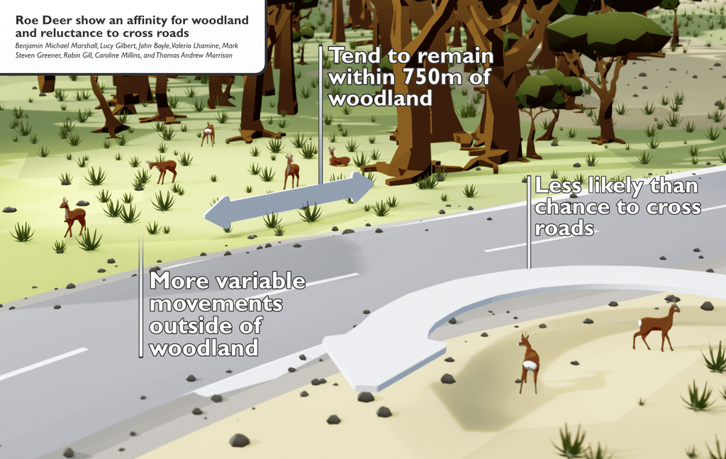

# 1 Introduction

Animals disproportionately use and move through some areas more than others. The study of these processes, i.e., habitat selection and movement, provides insights into the dynamic relationship between an animals’ physiology and the set of resources and risks occurring in landscapes (Manly, McDonald & Thomas, 1993; Gallagher et al., 2017). The balance between habitat, energy, risk, and resources determine the spatial distribution of populations, while also fundamentally underpinning demographic performance (Matthiopoulos et al., 2015; Gallagher et al., 2017). Accelerating landscape changes in the form of habitat destruction, creation and transformation increases the urgency for understanding if and how animals adjust movements to accommodate landscape changes.

Animal responses to landscapes can be hard to predict. At the global scale, wildlife movement is significantly impacted by human presence (Tucker et al., 2018). Mammals and reptiles broadly experience reductions in movement, with mobility limited by human-created barriers [e.g., roads or fencing; Tucker et al. (2018); Jerina (2012); Jones et al. (2019)]. Similarly, examinations of 586 mammal species show that home range sizes are roughly five times smaller in areas with high versus low human disturbance (Broekman et al., 2024). All else being equal, habitat fragmentation can also increase travel time for resource acquisition, resulting in higher energy expenditure (Doherty & Driscoll, 2018), shifts in diets (Redpath, 1995), and lower breeding success (Saunders, 1982).

Large herbivores, with relatively high mobility and large home ranges, often experience interactions with humans, domesticated animals, and infrastructure. Due to their economic importance and ecological impact, the space use patterns of large herbivores and their responses to anthropogenic features have been relatively well studied. Infrastructure such as roads and fences tend to degrade and fragment habitat, altering animal movement paths (Sawyer et al., 2013; Schwandner et al., 2025) and behaviour (Xu et al., 2021). However, movement responses to specific landscape features can be complex. For example, GPS-tagged Guanacos in Argentina were attracted to roads for grazing resources and low predation risk, but they strongly avoided crossing roads (Serota et al., 2024). By understanding movement responses, we may be better placed to predict and mitigate harmful interactions between wildlife and humans.

Deer live near humans in many temperate regions of the world and, as such, receive considerable attention from land managers (Cederlund, 1983; Dupke et al., 2017). In many areas, efforts are taken to control deer space use and population density, depending on the local management objectives (Pepper, Barbour & Glass, 2020). Objectives include reducing deer vehicular collisions, reducing damage to agriculture through disease transmission to livestock or herbivory, reducing vectors of disease to humans (e.g., ticks such as *Ixodes ricinus*), improving forestry productivity, enhancing biodiversity and woodland regeneration, and increasing hunting conditions (Putman et al., 2011). Deer population management could be improved by more precise knowledge of the movement behaviour and space use of deer; such knowledge could provide a more complete understanding from which controversial approaches to deer management can be assessed. While there is a history of individual-level tracking of deer in mainland Europe and North America (Morellet et al., 2013; Mysterud et al., 2025), only a handful of similar studies have been carried out on British deer (10 Red Deer *Cervus elaphus* in Glenbranter Forest, South Argyll Catt & Staines (1987); 36 Reeves’s Muntjac Deer *Muntiacus reevesi*, 7 Roe Deer *Capreolus capreolus* in The King’s Forest, Suffolk Chapman et al. (1993); 23 Muntjac Deer, 19 Fallow Deer *Dama dama* in Rockingham Forest and Monks Wood, Northamptonshire Staines et al. (1998)), with most research attention in the UK focused on other deer species (Staines et al., 1998; Broekman et al., 2023). Comparatively, Roe Deer movements remain understudied in parts of the UK such as Scotland (Mitchell, Staines & Welch, 1977) despite being the most abundant species in the UK, living most closely with humans, and the most frequently involved in deer-vehicle collisions (Lush & Lush, 2026). The need for individual level tracking of Roe Deer is apparent to gain a fuller understanding of their habitat requirements and reactions to human activities.

Roe deer are the smallest native deer species in the United Kingdom and the most ubiquitous, covering almost all the British mainland from the northern highlands of Scotland to the south coast of England (Staines et al., 1998; Burbaiteė & Csányi, 2009). Roe deer are woodland edge species that use isolated fragments of woodland, open or cultivated habitats near woody cover, and even gardens in and near urban areas (Staines et al., 1998). Their flexibility in terms of diet and space use allow widespread acclimatisation to a variety of ecological contexts and tolerate high levels of human disturbance (Jepsen & Topping, 2004; Ewald et al., 2014; Basak et al., 2020). When this adaptability is paired with a lack of natural predators and infrastructure expansion, Roe Deer can become frequently embroiled in human-wildlife conflict over forest management and deer-vehicle collisions (Putman et al., 2011; Lush & Lush, 2026).

Here we expand the knowledge of Roe Deer movement, targeting two different landscapes in the UK. We aim to document space use of UK Roe Deer, while exploring their movement in relation to various anthropogenic land cover types (cropland and settlements) and anthropogenic features, with a particular focus on roads.

# 2 Methods

## 2.1 Roe Deer Tracking

The study was conducted in two regions: in Northeastern Scotland (Aberdeenshire) and in Southern England in and around the New Forest National Park (Wiltshire and Hampshire, England; Fig. 2.1). Broadly, both locations represent mixed-use landscapes comprised of patches of woodland surrounded by cultivated agriculture, livestock pasture and buildings. Deer were captured to attach GPS collars, all being captured in woodland patches, during winter months (January - March in 2023) and (January - March 2024).

- The Muir of Dinnet is a National Nature Reserve managed by NatureScot, the Scottish Government’s statutory conservation agency, in the east of the Cairngorms National Park. The reserve consists of mainly mixed woodland dominated by birch (*Betula spp.*) and Scot’s Pine (*Pinus sylvestris*) with extensive areas of naturally regenerating Aspen (*Populus tremula*) and patches of heath and bogs.
- Black Hillocks is managed by the Glendye Estate and includes a patch of coniferous forest dominated by Scot’s Pine and European Larch (*Larix decidua*) surrounded by open upland heathland. Within 300m of the site, is the edge of a large tract of commercial, densely planted, mature conifer forest dominated by exotic species such as Sitka Spruce (*Picea sitchensis*).
- Wellhouse Woods is a commercial Sitka Spruce plantation surrounded by farmland pasture.
- Moss of Air, near Garlogie is a mixed woodland including Scot’s Pine and birch, surrounded by a mosaic landscape consisting of patches of commercial conifer forest, arable and pasture farmland.
- Gaskwood, also near Garlogie, is a commercial conifer forest including Scot’s Pine and Sitka spruce, within a mosaic landscape of forest and farmland patches, located 1 km across open farmland from Moss of Air.
- Holly Hatch and Kings Garn in Hampshire are both within the New Forest National Park. Both sites are a mix of mature deciduous (Oak *Quercus spp.* and Beech *Fagus spp.*) and coniferous trees. Holly Hatch also has dense stands of spruce saplings, surrounded by heathland. Both areas also support other large herbivores, including cattle, ponies, donkeys, Fallow Deer, Red Deer and Muntjac Deer.

We captured adult Roe Deer under Home Office Licence Project licence (PP1285683); a Nature Scot Research Authorisation licence to capture Roe Deer (16759); and a Natural England licence To Take deer Alive for Science, Education and Relocation to capture Roe and Fallow Deer (2022-63493-SPM-WLM). We employed a “long net” capture method (Cockburn, 1976), which has been used extensively and safely to capture Roe Deer in the UK (Gill et al., 1996) and elsewhere (Morellet et al., 2009).

Briefly, we set up 1-2 km of 2-metre-high nylon nets placed along paths, clearings and the edges of woodland patches. Nets were suspended on evenly spaced flexible bamboo poles. These nets then dropped off the poles to the ground and entangled the deer when they ran into them. Nets were placed in the shape of a horseshoe. Capture personnel were spaced every ~50m on the inside part of the netting area. A team of beaters, spaced every 10-15m, moved slowly from the open side of the horseshoe towards the top of the horseshoe. When a deer was caught in the net, the capture team restrained the animal, checked for any injuries, and for general health, estimated the age as either adult or juvenile and determined the sex. Juvenile deer were released. If the animal was judged to be in adequate health, and an adult it was injected intramuscularly with a sedative (Acepromazine (ACP Injection 2mg/ml, Elanco UK AH Limited), at a dose rate of 0.75ml (1.5mg) per deer. The heart rate, respiratory rate and temperature were monitored at capture, and every 5 minutes during subsequent handling. The deer was transferred to a wooden crate designed and built to safely retain the deer for at least 30 minutes for the sedative to take effect, which helped to calm the animal and reduced stress during subsequent handling. After 30 minutes to 1 hour, we removed the deer from the box and attached a GPS collar. Due to the use of sedative, an ear tag with a unique numeric identifier and “do not eat” was attached, along side an ear notch. This tag and notch were used to identify the animal following detachment of the collar and indicate that the deer should not enter the food chain if killed by a stalker. The deer was then released in a safe area away from any hazards.

We fitted captured adult Roe Deer with a GPS collar (30mm reinforced Tellus GP Light Iridium by Followit) that weighed 276g, representing <2% of the average Roe Deer total body mass. Following release, deer were closely monitored for ~10 days with high frequency (30 minute) GPS fixes and daily data transmission to detect any unusual behaviour (e.g., erratic movements, or small daily displacement) indicative of collar or capture trauma. After the initial monitoring period, collars collected GPS fixes every 3 hours in Aberdeenshire, and every 30 minutes in Hampshire. Collars in Hampshire were detached after a short duration (~1 month) due to evidence from one animal that the collar may have caused some friction to the neck. As a result, the Hampshire dataset is more limited in overall duration.

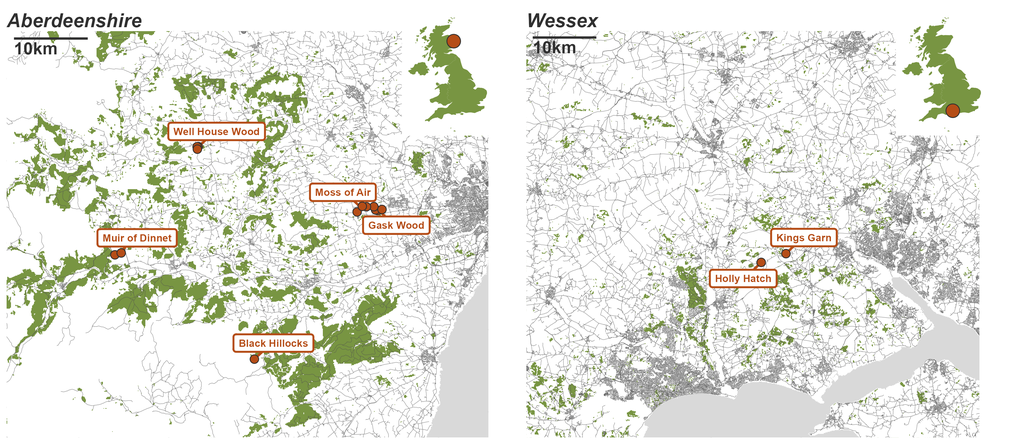

Table 2.1: Summary of tracking data used in analysis. Deer ID suffix denotes the sex of the individual deer.

| Location | Forest Area | Deer ID | Duration (days) | Number of fixes | Fixes per day | Mean lag between fixes (hours) |
| --- | --- | --- | --- | --- | --- | --- |
| Aberdeenshie | Gask Wood | Roe01_F | 252.50 | 1799 | 7.12 | 3.37 ±1.49 |
| Aberdeenshie | Gask Wood | Roe02_F | 255.50 | 1805 | 7.06 | 3.4 ±1.61 |
| Aberdeenshie | Gask Wood | Roe04_F | 248.50 | 1787 | 7.19 | 3.34 ±1.45 |
| Aberdeenshie | Muir of Dinnet | Roe05_F | 101.88 | 676 | 6.64 | 3.62 ±1.18 |
| Aberdeenshie | Moss of air | Roe06_F | 282.50 | 1938 | 6.86 | 3.5 ±1.57 |
| Aberdeenshie | Gask Wood | Roe08_M | 250.50 | 1799 | 7.18 | 3.34 ±1.42 |
| Aberdeenshie | Black Hillocks | Roe09_M | 254.50 | 1821 | 7.16 | 3.36 ±1.44 |
| Aberdeenshie | Muir of Dinnet | Roe10_F | 270.50 | 1873 | 6.92 | 3.47 ±1.6 |
| Aberdeenshie | Well House Wood | Roe11_F | 67.88 | 548 | 8.07 | 2.98 ±0.15 |
| Aberdeenshie | Well House Wood | Roe12_F | 139.88 | 1120 | 8.01 | 3 ±0.21 |
| Aberdeenshie | Moss of air | Roe13_F | 280.50 | 1931 | 6.88 | 3.49 ±1.53 |
| Aberdeenshie | Well House Wood | Roe14_M | 149.88 | 1201 | 8.01 | 3 ±0.18 |
| Aberdeenshie | Moss of air | Roe15_F | 282.50 | 1932 | 6.84 | 3.51 ±1.59 |
| Hampshire | Kings Garn | Roe03_M | 49.88 | 305 | 6.11 | 3.94 ±1.81 |
| Hampshire | Holly Hatch | Roe07_F | 52.92 | 368 | 6.95 | 3.46 ±1.67 |

We retrieved movement data from 15 GPS collars worn by Roe Deer, 13 in Aberdeenshire, 2 in Hampshire. We re-sampled the Roe Deer data to a more consistent rate, aiming for a standard 3 hour time lag between locations (with a 1 hour tolerance). We additionally filtered out the first weeks’ worth of data to avoid the impacts of capture/immediate post-release movements that may have been atypical (Morellet et al., 2009).

## 2.2 Home Range Estimation

We estimated Roe Deer home range using Autocorrelated Kernel Density Estimators [AKDE; Fleming & Calabrese (2023); Calabrese, Fleming & Gurarie (2016); Fleming et al. (2015); Fleming & Calabrese (2017)]; a method of home range area estimation that accounts for the particular structures present in movement data such as autocorrelation and data gaps. This process consisted of fitting a number of continuous time movement models to an individual deer’s movement data, selecting the best fitting movement model, and extracting a suitable range contour from the resulting utilisation distribution. We fit the following models (following the default process provided by the ctmm package): Ornstein-Uhlenbeck (OU), Ornstein–Uhlenbeck Foraging (OUF), and Independent Identically Distributed (IID), all in both isotropic and anisotropic forms. We elected to use perturbative hybrid residual maximum likelihood (pHREML) (Fleming et al., 2019; Silva et al., 2022) and AICc to determine the best fitting movement model on an individual basis, and used that single best fitting model for all further estimations.

Before committing to the estimations of home range size we examined whether the Roe Deer exhibited stable ranges through the visual inspection of variograms. A stable range should be revealed by a clear asymptote in variogram, where the semi-variance flattens as time lags increase. We paired these visual inspections with a judgement of effective sample size to help gauge our confidence in the home range area estimates [effective sample size approximating the overall tracking duration divided by the mean time taken to cross the home range; Silva et al. (2022)]. All our individuals showed effective sample sizes between 154.4 and 926.7, indicating that the movement data contained a large number of complete home range crossing events, allowing us to be confident in overall home range estimates.

Having determined the data’s suitability for home range estimations, we extracted the 95% and 99% contours from the weighted AKDE estimate, alongside 95% confidence interval surrounding that contour. We selected 95% for further estimate mean ranges as it struck a balance between a generous estimate of home range, while also avoiding the undue influence of the most extremely outlying movements. To generate an overall home range estimate for Aberdeenshire Roe Deer, we averaged the home ranges using the weighted mean function provided by the ctmm package (Silva et al., 2022; Fleming & Calabrese, 2023). This way the home range mean is weighted by the confidence (i.e., effective sample size) surrounding each home range.

We retained 99% contour estimates to help quantify the distance from which Roe Deer will range away from woodland patches. We calculated the widest dimension of each 99% home range polygon (or largest polygon if the home range area was non-contiguous), and halved that value to quantify the distance deer would be willing to travel beyond their resident patch. To support this approach and to produce an overall distribution deer distance away from woodland patches, we determined how far every deer location was from the nearest patch and plotted those values against the distance estimated by the home range models.

## 2.3 Habitat Selection

We used the reformulated Poisson model approach described by Muff, Signer & Fieberg (2020) to generate population level estimates of habitat selection as well as gauge deer’s movement capabilities in relation to different aspects of the landscape.

The model required data pertaining to the used locations (i.e., GPS locations of the deer) and comparable data on randomly generated available points (i.e., randomly generated locations the deer could have travelled to). For each confirmed deer location, we generated 10 random alternative locations they could have travelled to. The location of these random locations was governed by two distributions. A Gamma distribution from which random step lengths were drawn from, and a Von Mises distribution from which random turn directions were drawn from. Both distribution were calibrated (e.g., shape, size, mu, and kappa) by the underlying movement data.

Once all random locations had been generated, we extracted a suite of environmental variables at all those locations, in order to relate Roe Deer space use with land cover and anthropogenic features. First was the land cover type as described by the 2023 UKCEH land cover maps, which is a 25m resolution classified raster originally based on Sentinel-2 imagery (Morton et al., 2024). Validation of these data suggest 83% accuracy (Morton et al., 2024). The UKCEH land cover data comprises of 21 land cover classes, broadly following the Biodiversity Broad Habitats (Jackson, 2000).

We recategorised these 21 land cover types categories into 10 more general categories (Tab. 2.2. This reduced instances of limited interaction with the deer movement data thereby aiding habitat selection model convergence and avoided extreme, unstable selection estimates.

Table 2.2: Overview of the reclassification of UKCEH land cover classes for inclusion into the habitat selection models.

| UKCEH land cover class | UKCEH land cover identifier | Reclassified category |
| --- | --- | --- |
| Deciduous woodland | 1 | Deciduous Broadleaf Forest |
| Coniferous woodland | 2 | Evergreen Needleleaf Forest |
| Arable | 3 | Cropland |
| Improved grassland | 4 | Tall Grassland |
| Neutral grassland | 5 | Short Grassland |
| Calcareous grassland | 6 | Short Grassland |
| Acid grassland | 7 | Short Grassland |
| Fen | 8 | Permanent Wetland |
| Heather | 9 | Open Shrubland |
| Heather grassland | 10 | Open Shrubland |
| Bog | 11 | Permanent Wetland |
| Inland rock | 12 | Barren |
| Saltwater | 13 | Other |
| Freshwater | 14 | Other |
| Supralittoral rock | 15 | Barren |
| Supralittoral sediment | 16 | Barren |
| Littoral rock | 17 | Barren |
| Littoral sediment | 18 | Barren |
| Saltmarsh | 19 | Permanent Wetland |
| Urban | 20 | Human Settlements |
| Suburban | 21 | Human Settlements |

In addition to land cover classes, we also acquired “woody linear feature” (i.e., hedgerows) data from UKCEH (Scholefield et al., 2016), which maps hedgerows across the UK (e.g., woodland) as polylines, based on Ordnance Survey maps and the 2007 UKCEH Land Cover Map (Morton et al., 2011).

We converted the polygon spatial data into a raster, where 1 == hedgerow, and used that rasterisation to generate a distance to hedgerow raster for the entire study landscape. We conducted the same process to create a distance to woodland raster, where we calculated the distance from any area the UKCEH land cover data classed as deciduous or coniferous woodland. These distance rasters allowed for easy extraction of the distance to the nearest hedgerow and woodland for all locations. This allowed us to investigate the influence of woodland or hedgerow on the use of open habitats by Roe Deer, as well as the extent to which expanses of open habitats might act as barriers to Roe Deer dispersal.

We acquired road data from Ordnance Survey Open Roads dataset (Ordnance Survey, 2024). We created a binary variable describing crossing events for all steps, with all steps that crossed one or more of the roads being classed as 1. This binary variable allowed us to estimate the likelihood Roe Deer cross a road and therefore the extent to which roads may present a barrier (Serota et al., 2024).

To ensure compatibility between all data sources, we projected all data into the British National Grid (BNG) coordinate reference system (OSGB36, epsg: 27700) before undertaking analysis.

The population level model consisted of land cover (a 8-term category variable formed into 7 dummy variables, with deciduous woodland placed as the reference category, barren and other excluded), distance to woodland (continuous in m), distance to hedgerow (continuous in m), road crossing (binary). In addition to these habitat selection focused predictors, we included several movement predictors: step length, log step length, and cos turn angle, as well as the interaction between step length and log of step length with all land cover types.

To account for the structure originating from having multiple individuals in the model, we included fixed Gaussian processes for the time step and the individual in keeping with the approach described by Muff, Signer & Fieberg (2020). This formulation, namely the fixed Gaussian processes, as described by Muff, Signer & Fieberg (2020) allows for the efficient estimation of population level selection using integrated nested Laplace approximation (INLA) (Martins et al., 2013; Lindgren & Rue, 2015). Our final formula was: *y ~ -1 + Distance to woodland (continuous) + Distance to hedgerows (continuous) + Land cover categories (7 binary variables) + Road crossed (binary) + Step length (continuous) + Log step length (continuous) + Cos turn angle (continuous) + Step length interactions with Land cover categories + Log step length interactions with Land cover categories + Gaussian process for deer ID + Gaussian process for time step*.

To supplement the population model, we ran individual level step-selection models for each Roe Deer separately. These models used the same data as the population level model, but focused on individual level responses relative to the population mean. Past studies of wild Roe Deer have found substantial levels of individual variability in behavioural responses to risk (Bonnot et al., 2015). For the individual models, we used a formula that included land cover class, distance to woodland, distance to hedgerows, a binary describing whether they crossed a road, step length, log step length, and cos of turn angle. Once we had estimated individual responses to the environmental variables, we explore how the variation in individual coefficients could highlight individual variability in selection. We used the IndRSA package (Bastille-Rousseau, 2025) to explore the variation of resulting coefficients (i.e., selection or attraction towards environmental characteristics), producing population-level estimates of specialisation, heterogeneity, and a weighted population mean (Bastille‐Rousseau & Wittemyer, 2022). Specialisation is the absolute magnitude of the coefficients; differences compared to the population mean coefficient could highlight diverging responses to the habitat covariates and a bimodal response to a given environmental characteristic. This can be particularity informative when the diverging responses have resulted in a “neutral” population mean for the coefficient. Heterogeneity is the standard deviation of the coefficients; therefore, larger values indicate greater variation between individual Roe Deer in their response to land cover or landscape features. The weighted population mean provides an alternative measure of population level selection to our Poisson model. To carry forward the uncertainty surrounding the initial habitat coefficients in the weighted population mean, 10,000 replicates of each metric were generated from a normal distribution centred on the original coefficient with a standard deviation equal to the standard error of the coefficient (Bastille‐Rousseau & Wittemyer, 2022).

# 3 Results

Overall, the 15 GPS collared Roe Deer resulted in 20903 location fixes, with a mean of 1394 SD±627.9 per individual, spread across a mean of 196 SD±90.99 days per individual (Fig. 6.1). This resulted in an average of 7.133 SD±0.5359 fixes per day per individual (Fig. 6.2; Tab. 2.1).

For our Aberdeenshire Roe Deer home range sizes ranged from 32.2 to 122.5ha (95% contour point estimates), with a weighted mean of 65.3 ha (95% CI 55.5-75.8) (Fig. 3.1). The deer appeared range resident; however, a couple of individuals may show evidence of a range shift during the tracking period (Roe Deer 8 and Roe Deer 3; Fig. 6.3). Effective sample sizes were all high (154.4 and 926.7), suggesting we can be confident in the home range estimates. All except for two individuals (Roe Deer 5 and Roe Deer 12) found OU models to fit best, with the remaining two being better described by OUF models (Tab. 6.1).

All best fitting models were anisotropic, suggesting these Roe Deer are inhabiting non-uniform home ranges (i.e., not being as wide as they are long). The placement of home ranges suggest the importance of woodland, with 95% of all deer movements falling within 756 m of woodland (756 m is half of the longest dimension of the 99% home range area; thereby suggesting ranges tend to centre on woodland; Fig. 3.2).

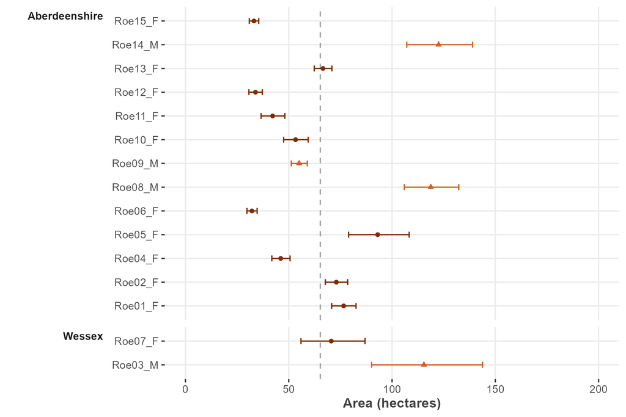

Figure 3.1: Home range size of Roe Deer in two landscapes as estimated via the Autocorrelated Kernel Density Estimators. Depicted are the 95% contour with 95% confidence intervals surrounding estimates for female (red circles) and male (orange triangles). The vertical line shows the weighted mean of Aberdeenshire home range estimates.

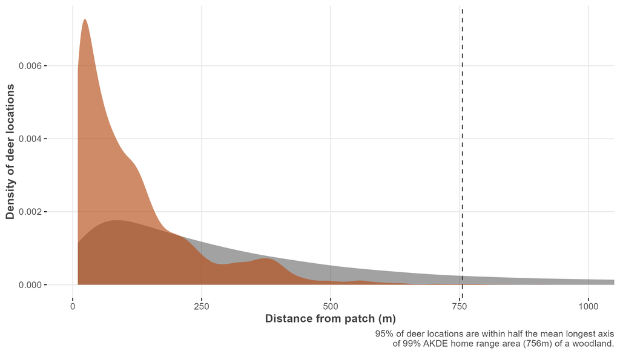

Figure 3.2: Distribution of Roe Deer locations in relation to their distance from woodland patches (Orange) compared to the distribution of random locations throughout the landscape in relation to their distance from woodland patches (Grey). Locations within woodland are excluded. Vertical dashed line shows the half longest dimension of the 99% home range area.

## 3.1 Population level selection

The population level habitat selection model revealed a general tendency for Roe Deer to remain closer to the woodland patches (-0.0051; 95% CI -0.0082 to -0.0022), with no significant selection for hedgerows (-9e-04; 95% CI -0.0019 to 1e-04; Fig. 3.3). The model also revealed that roads play a significant role in reducing connectivity across the landscape: observed deer steps were significantly less likely to cross roads than random steps (-0.76; 95% CI -1.2 to -0.36). The population habitat selection model also revealed significant selection for the land cover classes open shrubland (1.5; 95% CI 0.62 to 2.2) and tall grassland (0.57; 95% CI 0.17 to 0.98); other relationships were less clear (Tab. 6.2).

The model’s inclusion of step length and log step length interactions allowed us to examine whether movement was altered by land cover. Movement was most impacted by short grassland, tall grassland, and cropland, all showing the same pattern. The step lengths in these land covers tended to be lower (i.e., slower movement), as seen in coefficients for log step length (short grassland -0.76; 95% CI -1.2 to -0.32; tall grassland -0.18; 95% CI -0.24 to -0.12; cropland -0.16; 95% CI -0.24 to -0.078) but with a larger tail to the Gamma distribution (i.e., larger coefficient for step lengths; short grassland 0.0044; 95% CI 0.0018 to 0.007; tall grassland 0.00048; 95% CI 5.1e-05 to 0.00092; cropland 0.0012; 95% CI 0.00064 to 0.0017). Combined this could be indicative of more stop-start movements and behaviours.

Estimates regarding human settlements were paired with very wide confidence intervals (-70; 95% CI -180 to 36), likely a result of minimal overlap between the Roe Deer movement data (and any associated random available points) and human settlements making estimation difficult.

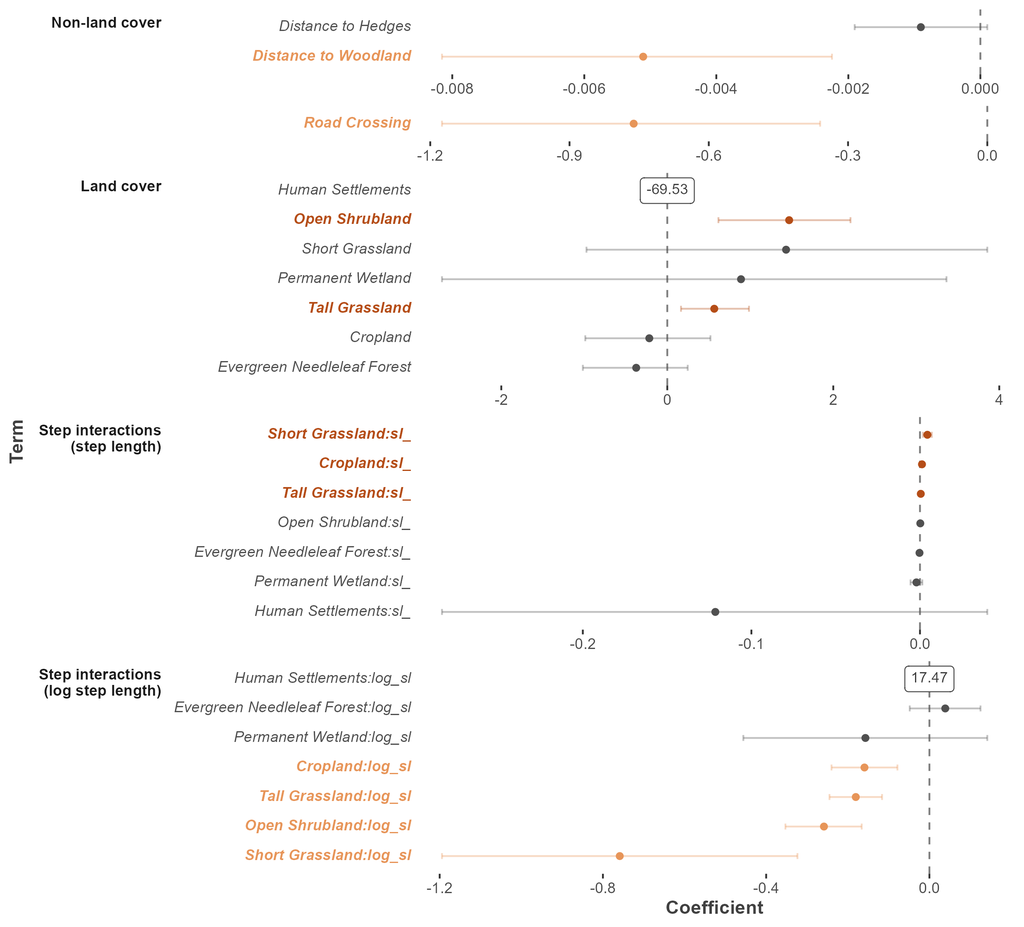

Figure 3.3: Coefficient estimates, with 95% confidence intervals, from the population level model of habitat selection for all 15 Roe Deer. For distance to * variables, lower coefficients indicate that Roe Deer are selecting areas with lower distances from the landscape feature. For the road crossing variable, lower coefficients indicate a lower than chance to cross the road. For land cover variables, positive coefficients indicate of Roe Deer preferentially selecting to be in those areas. For step length interactions, positive coefficient interactions with step lengths indicate a longer tail to the overall distribution of step lengths when Roe Deer are in a given land cover class. A positive coefficient with log step lengths indicate a larger step lengths when Roe Deer are in a given land cover class. Central numeric labels report majorly outlying estimates to aid visualisation. Colour highlights and bolding reflect the significantly negative (light orange) and significantly positive (dark orange) coefficients. Note x axes are different per variable type.

## 3.2 Individual level selection and variation in selection

Further exploration of individual habitat selection models highlights whether the uncertainty in the population level model stems from weak responses or diverging responses that average towards a zero effect (Tab. 6.3; Tab. 6.4). Distance to woodland shows a marginally higher specialisation (0.01) compared to the weighted population mean (-0.005; 95% CI -0.009 to -0.001; Fig. 3.4). This difference is likely explained by the deviating Roe 10 who expressed an opposite response to the majority of other deer by expressing an aversion to woodland (0.006 ±0.001). Apart from Roe 10, Roe Deer are exhibiting the same clear preference for remaining near woodland as seen in the population level model. Roe 10 is also likely the reason the estimated heterogeneity in response to distance to woodland (0.0134) is greater than distance to hedgerows (0.0019; Fig. 6.4).

Distance to hedgerows does not see the same consistent response, instead with a number of individuals showing a opposing responses. This is reflected in the population mean being close to zero (-0.001; 95% CI -0.002 to 0), while the specialisation is greater (0.002; Fig. 6.5), the combination of which could indicate two differing responses to hedgerows in the sampled Roe Deer.

The chance of crossing a road is considerably more consistent, with the vast majority of individuals preferring not to cross roads; this is reflected in a significantly negative population mean (-0.514; 95% CI -0.807 to -0.222). The elevated specialisation (134.97) and heterogeneity (417.65) values are almost entirely driven by two very uncertain estimates from Roe Deer 09 (17.957 ±888.36) and Roe Deer 11 (-17.988 ±1620.795). This could have been the result of a lack of exposure; the Roe Deer 09 only crossed roads on two occasions, while Roe Deer 11 never did. Other than those individuals, we can be confident in a consistently negative response to road crossing in Roe Deer.

It was difficult to obtain confident estimates for land cover categories due to the variable levels of availability for each individual; some individuals only rarely moved close enough to certain land cover classes so estimations are based on a small section of the movement dataset. Cropland and Evergreen Needleleaf Forest showed the high rates of significant estimates, and both weighted population estimates (-0.191; 95% CI -0.561 to 0.179; -0.072; 95% CI -0.311 to 0.168) matched the results from the Poisson population level model (-0.22; 95% CI -0.99 to 0.52; -0.37; 95% CI -1 to 0.25). In both cases a single individual revealed a strong but very uncertain negative response that can explain the heterogeneity (353.18; 252.83) and specialisation values (107.22; 68.37) and additionally explain why the effect overlapped zero in the Population level model. The response to Evergreen Needleleaf Forest appears the least consistent, with multiple individuals expressing significantly negative and positive responses to the land cover. Tall Grassland showed similar levels of diverging estimates, with individuals showing a mix of positive and negative responses. Unlike the population estimates for Cropland and Evergreen Needleleaf Forest, the weighted population mean for Tall Grassland (-0.299; 95% CI -0.572 to -0.026) does not match the population level model (0.57; 95% CI 0.17 to 0.98). This may be indicative that the interaction effects included in the population level model are mediating the responses to Tall Grassland. A similar reason may explain the clear Open Shrubland response in the population level model (1.5; 95% CI 0.62 to 2.2) that is absent in the individual models and the resulting weighted population mean (0.028; 95% CI -0.633 to 0.69); however, this is more likely to be caused by the limited number of individuals exposed to Open Shrubland and a different handling of Roe Deer 03’s strongly negative response. The other land covers are all harder to confidently interpret given the frequency of very uncertain extreme estimates. The uncertainty surrounding Human Settlements and Permanent Wetland is well reflected in the population level model. The high levels of specialisation and heterogeneity are driven by these same extreme estimates. The lack of consistent availability of these land covers and potentially inconsistent response leaves a lot of uncertainty concerning Roe Deer response to these land covers.

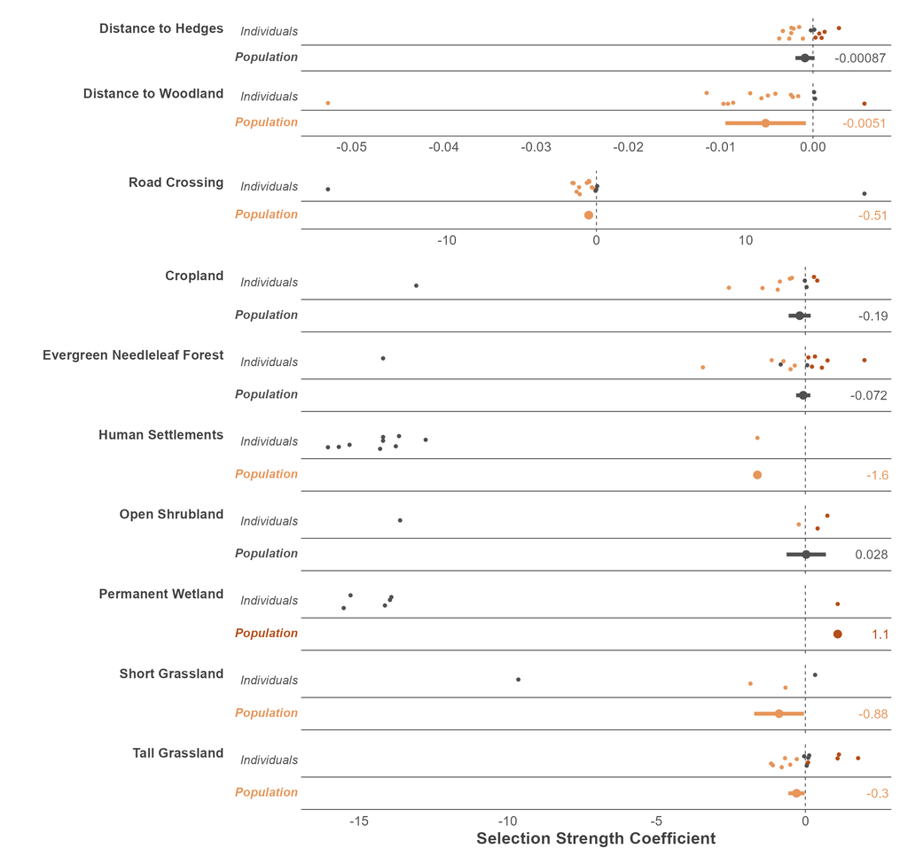

Figure 3.4: Coefficient estimates for all individual step-selection models for all 15 Roe Deer, along side weighted population means per covariate. Points indicate the estimated coefficients for each individual. Error bars with the population estimates are the 95% confidence interval. Colour highlights reflect the estimates whose standard errors do not overlap zero, either negatively (light orange) and positively (dark orange). For distance to * variables, lower coefficients indicate that Roe Deer are selecting areas with lower distances from the landscape feature. For the road crossing variable, lower coefficients indicate a lower than chance to cross the road. For land cover variables, positive coefficients indicate of Roe Deer preferentially selecting to be in those areas.

# 4 Discussion

Our findings on Roe Deer home range size are similar to those values reported in the HomeRange database for Roe Deer (approx. 105 Roe Deer; Fig. 6.6), with the database presenting examples of both ranges larger and smaller than exhibited by our 15 individuals (Broekman et al. (2023); Broekman et al. (2022); see references in data availability section). This similarity in home range sizes is somewhat speculative given it does not account for differences in sampling protocol, duration, or home range estimation method, all of which can modify estimated home range size (Silva et al., 2020). Despite the simple comparison, the UK Roe Deer examined in our study appear to be largely typical in regards to their home range size. Some of the variation in home range has been suggested to be a product of food accessibility and the arrangement of cover from predators (Tufto, Andersen & Linnell, 1996; Saïd & Servanty, 2005; Saïd et al., 2009), as well as dynamic in relation to reproduction (Saïd et al., 2005).

Other examinations of Roe Deer have highlighted the importance of risk guiding when Roe Deer leave their core wooded range to make use of more open areas (Venkatesan et al., IN PREP - 2026; Bonnot et al., 2015; Padié et al., 2015). The potential benefits of managing this risk to reap the nutritional benefits afforded by open areas are apparent (Hewison et al., 2009), and may present a direct trade off against the risks posed by humans when in more open areas. Humans are likely the UK Roe Deer’s primary concern, as other predators such as Lynx, which require different risk mitigating decisions, are absent in the UK (Lone et al., 2014). The shifts in movements (i.e., step lengths) we report here may be a coarse representation of Roe Deer balancing the risk and benefits in crop- and grasslands. Such trade-offs may be more pronounced in more fragmented or riskier landscapes, and could also explain the lack of consistent selection to remain near hedgerows. Compared to other Roe Deer studies in area such as France, our Roe Deer may have easier access to wooded cover in a less fragmented landscape (Morellet et al., 2011); thereby, being less dependent on hedgerows. To tease apart the UK Roe Deer’s response to risk, a more complete quantification of human activity would be required, including presence of walkers, dogs, and hunting pressure.

Roe Deer in our study avoided crossing roads more than expected by chance, suggesting roads reduce landscape connectivity. Thus, in countries with high densities of roads, such as the UK, even limited road crossing avoidance by deer could potentially have impacts on deer population structure, dispersal, and movement of deer-associated parasites (e.g., ticks). Some deer-hosted *Ixodes ricinus* ticks carry pathogens significant for human and livestock health; therefore, this differential landscape permeability may have indirect health implications. Despite this avoidance, it was not complete and deer collisions with vehicles remain a key safety issue (Lush & Lush, 2026). In Scotland, higher rates of deer-vehicle collisions appear to occur in the vicinity of woodland and other semi-natural habitats (Langbein, 2019), with road junctions being key hotspots (Lush & Lush, 2026). Other studies have highlighted the importance of road density in Roe Deer home ranges as a key predictor of road crossing frequency (Kämmerle et al., 2017), further supporting the woodland-road proximity connection. Traffic flow also plays a role in the likelihood of a road section experiencing collisions (Nelli et al., 2018), highlighting that the ultimate impact of roads will be a product of deer and human factors. For example, while urban areas tend to lower deer-vehicle collision risk, the intersection of urban and natural areas (i.e., suburban) may result in risk hotspots where both deer and traffic collide (Nelli et al., 2018). This non-linear relationship between animal densities, their reaction and activity close to roads, and the intensity of traffic makes road-wildlife collision difficult to completely characterise and generalise (Valero et al., 2015; Abraham & Mumma, 2021; Cunningham et al., 2022; Denneboom, Bar‐Massada & Shwartz, 2024). The estimation of Roe Deer crossing tendency here, will help refine our understanding of that relationship in the UK. Other Roe Deer investigations have revealed similar preferences for forest and reluctance to cross roads (Passoni et al., 2021), and that the risks fluctuate over the day and year (Cunningham et al., 2022; Märtz, Brieger & Bhardwaj, 2024; Lush & Lush, 2026).

There are several aspects of the study that may limit its generalisability, or that would need to be considered when applying the findings to other contexts. Using the STRANGE framework (Webster & Rutz, 2020), we highlight key limitations (omitting those that are unquantifiable or of limited relevance). **Social background**. We have little information on the individuals not tracked that may be impacting the movements of tracked deer. Roe Deer will maintain territories (Hoem et al., 2007; Pagon et al., 2017), so it is likely that the density of and interactions with conspecifics could alter the distribution and size of our tracked deer’s movements via competitive exclusion or territorial patrolling. **Trappability and self-selection**. While there is not obvious bias to the deer trapping methods we used, there may be an unknown behavioural variation altering the likelihood of a deer being captured. If the trappability of a deer is associated with certain movement or behavioural parameters, our sample may be skewed towards those tendencies (e.g., boldness leads to increased capture likelihood, while also being connected to increased chance of crossing roads). Long-term studies of individually-tagged Roe Deer in France have detected behavioural and body size differences between deer associated with woodlands versus open or cultivated landcover (Hewison et al., 2009). Given deer were exclusively trapped in woodlands in our study, we may have overestimated the strength of woodland preferences for some Roe Deer, and in areas with more continuous woodlands, deer may prefer open habitat more strongly (Hewison et al., 2001). Nonetheless, Roe Deer in general are undoubtedly strongly woodland associated (Gill et al., 1996) and need shrubby or herbaceous cover for hiding and foraging. **Acclimation and habituation**. None of the deer had been previously collared, but there may have been a habituation effect to collars over time. Our removal of the first week of data likely have mitigated the largest impact prior to collar-habituation, but as the Hampshire deer demonstrate there may be ongoing effects we cannot control for. Further explorations for longer tracking periods and with different age groups may elucidate the collar and human habituation effects.

Overall, we documented a tendency for Roe Deer to remain close to woodland in the UK. This pattern apparently limits their ranges to areas within 750m of woodland patches. The resulting home ranges of UK Roe Deer do not appear atypical when compared to other tracked Roe Deer. We see a clear and consistent, albeit slight, aversion to crossing roads that may be limiting the permeability of the landscape for Roe Deer. Further work could benefit from focusing on UK Roe Deer in areas with a greater urban footprint, or comparing movements against more granular quantifications of human activity (Gomez et al., 2025).

# 5 Acknowledgements

We are indebted to the hundreds of volunteers who assisted in the deployment of deer GPS collars. We especially thank Mark Hewison, Jochen Langbein, Tim Dansie, Andy Page, Sandy Shore and Andy Shore for generous advice in the field and training in capture methods. This research forms part of the TickSolve project (https://ticksolve.ceh.ac.uk/) and was funded by UK Research and Innovation through the NERC grants NE/W003171/1 and NE/W003244/1. For permission to conduct the work, we thank NatureScot, ForestryEngland and NaturalEngland.

## 5.1 Software availability

For all analysis we used R (v.4.4.2) (R Core Team, 2024), and R Studio (v.2024.12.0+467) (Posit team, 2024). For analysis of animal movement data we used amt (v.0.2.2.0) (Signer, Fieberg & Avgar, 2019), ctmm (v.1.2.0) (Fleming & Calabrese, 2023), and move (v.4.2.6) (Kranstauber, Smolla & Scharf, 2024). For general data manipulation we used glue (v.1.8.0) (Hester & Bryan, 2024), sjmisc (v.2.8.10) (Lüdecke, 2018), tidyverse (v.2.0.0) (Wickham et al., 2019), and units (v.0.8.5) (Pebesma, Mailund & Hiebert, 2016). For project and code management we used here (v.1.0.1) (Müller, 2020), tarchetypes (v.0.11.0) (Landau, 2021a), and targets (v.1.9.0) (Landau, 2021b). For visualisation we used the following as expansions from the tidyverse suite of packages: ggdist (v.3.3.2) (Kay, 2024a,b), ggridges (v.0.5.6) (Wilke, 2024), ggtext (v.0.1.2) (Wilke & Wiernik, 2022), patchwork (v.1.3.0) (Pedersen, 2024), and scales (v.1.3.0) (Wickham, Pedersen & Seidel, 2023). Other packages we used were boot (v.1.3.31) (A. C. Davison & D. V. Hinkley, 1997; Angelo Canty & B. D. Ripley, 2024), circular (v.0.5.1) (Agostinelli & Lund, 2024), doParallel (v.1.0.17) (Corporation & Weston, 2022), foreach (v.1.5.2) (Microsoft & Weston, 2022), knitr (v.1.49) (Xie, 2014, 2015, 2024), and usethis (v.3.0.0) (Wickham et al., 2024). To generate typeset outputs we used bookdown (v.0.42) (Xie, 2016, 2025), and rmarkdown (v.2.29) (Xie, Allaire & Grolemund, 2018; Xie, Dervieux & Riederer, 2020; Allaire et al., 2024). To manipulate and manage spatial data we used gdistance (v.1.6.4) (van Etten, 2017), raster (v.3.6.30) (Hijmans, 2024a), sf (v.1.0.19) (Pebesma, 2018; Pebesma & Bivand, 2023), sp (v.2.1.4) (Pebesma & Bivand, 2005; Bivand, Pebesma & Gomez-Rubio, 2013), terra (v.1.7.83) (Hijmans, 2024b), and tidyterra (v.0.6.1) (Hernangómez, 2023). To run models and explore model outputs we used effects (v.4.2.2) (Fox, 2003; Fox & Hong, 2009; Fox & Weisberg, 2018, 2019), INLA (v.24.6.27) (Martins et al., 2013; Lindgren & Rue, 2015), lme4 (v.1.1.35.5) (Bates et al., 2015), and performance (v.0.12.4) (Lüdecke et al., 2021).

The code used to complete this study can be found at https://github.com/BenMMarshall/TICKSOLVE_DeerMovement amongst code for the broader examination of deer’s role in these landscapes; and is archived at https://doi.org/10.5281/zenodo.18701055.

We used Blender 4.5 LTS (Blender Online Community, 2025) and Affinity Publisher 2 (Serif, 2025) to create the graphical abstract visuals.

## 5.2 Data availability

Core data underlying these analyses can be found at: https://doi.org/10.5281/zenodo.18699746.

Aberdeenshire Roe Deer movement data can be accessed via Movebank https://www.movebank.org; Movebank ID 2890266958.

New Forest, Hampshire Roe Deer movement data can be accessed via Movebank https://www.movebank.org; Movebank ID 8086497234.

Studies that the HomeRange Database mean was based on: Melis, Cagnacci & Lovari (2005); Biosa et al. (2015); Dupke et al. (2017); Rossi et al. (2003); Focardi et al. (2006); Picardi et al. (2019); Ramanzin, Sturaro & Zanon (2007); Mysterud (1999); Ranc et al. (2020); Richard et al. (2008); Aiello, Lovari & Bocci (2013); Morellet et al. (2013); Vanpé et al. (2009); Pellerin et al. (2016); Kjellander et al. (2004); Van Laere, Boutin & Gaillard (1996); Cederlund (1983); Saïd et al. (2005); Bideau et al. (1993); Cimino & Lovari (2003); Lamberti et al. (2001); Lamberti et al. (2006); Bevanda et al. (2015); Pagon et al. (2017); Debeffe et al. (2012); Chapman et al. (1993); Lamberti, Mauri & Apollonio (2004); Maublanc et al. (2018); Padié et al. (2015); Saïd & Servanty (2005); Carvalho et al. (2008); Malagnino et al. (2021); Linnell & Andersen (1995); Rossi et al. (2001); Jeppesen (1990).

## 5.3 Author Contributions

Conceptualization: Caroline Millins and Thomas A. Morrison. Data curation: Thomas A. Morrison. Formal analysis: Benjamin M. Marshall. Funding acquisition: Lucy Gilbert, Caroline Millins, and Thomas A. Morrison. Investigation: John Boyle, Mark S. Greener, Robin Gill, Caroline Millins, and Thomas A. Morrison. Methodology: Benjamin M. Marshall, John Boyle, Mark S. Greener, Robin Gill, Caroline Millins, and Thomas A. Morrison. Project administration: Lucy Gilbert, Caroline Millins, and Thomas A. Morrison. Resources: Lucy Gilbert. Supervision: Lucy Gilbert and Mark S. Greener. Visualization: Benjamin M. Marshall. Writing - original draft: Benjamin M. Marshall, Valerio V. Lhamine, Caroline Millins, and Thomas A. Morrison. Writing - review & editing: Benjamin M. Marshall, Lucy Gilbert, John Boyle, Valerio V. Lhamine, Mark S. Greener, Robin Gill, Caroline Millins, and Thomas A. Morrison.

# 6 Supplementary Material

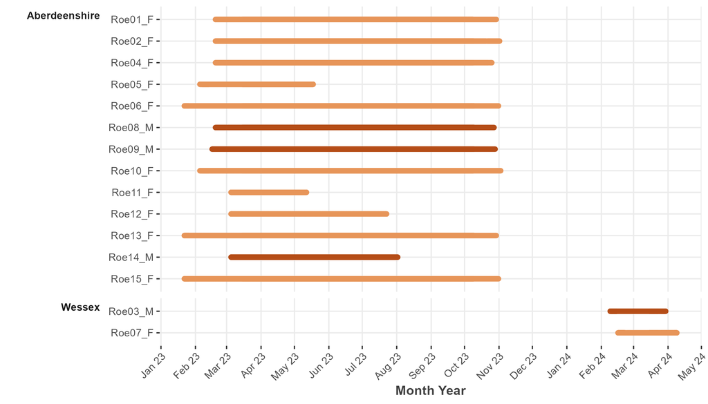

Figure 6.1: Dates of data collection and overall duration or deer tracking by individual.

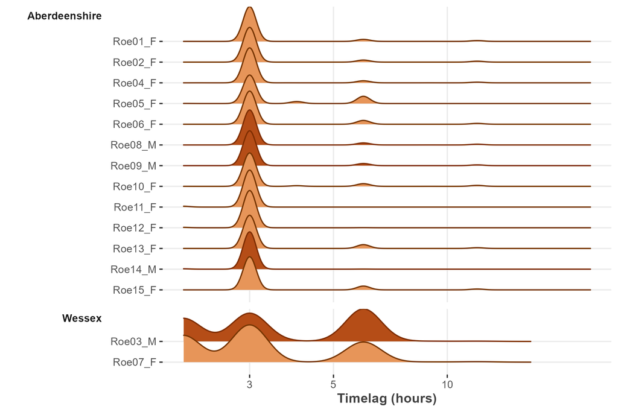

Figure 6.2: Distribution of time lags between Roe Deer location fixes. N.b. x axis is log scaled.

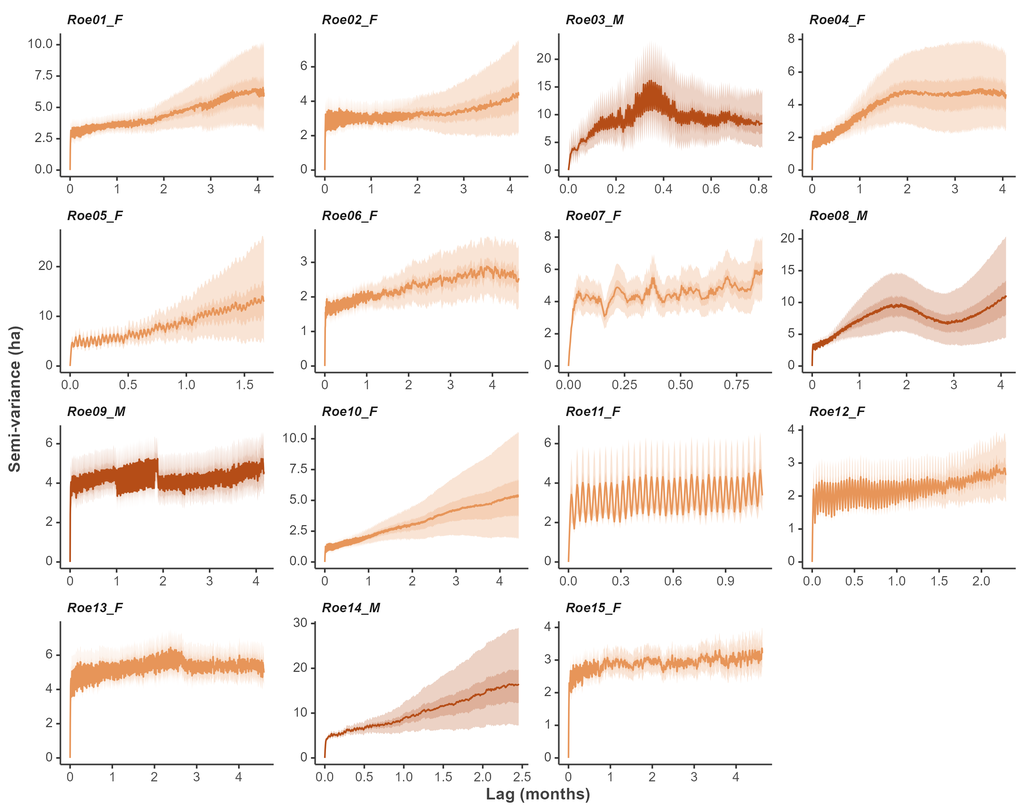

Figure 6.3: Variograms showing the autocorrelative structure of the Roe Deer movement data; The semi-variance (average square displacement) is show over a specific time lag. Examination reveals the level of range residency displayed by each individual (i.e., flattens to an asymptote).

Table 6.1: Overview of the area estimates resulting from the AKDEs. Area units are hectares. ESS = Effective Sample Size

| Region | Animal ID | Point Estimate | Lower CI | Upper CI | Contour level | ESS | Movement Model |
| --- | --- | --- | --- | --- | --- | --- | --- |
| Aberdeenshire | Roe01_F | 58.56 | 54.15 | 63.15 | 0.90 | 650.33 | OU anisotropic |
| Aberdeenshire | Roe01_F | 76.58 | 70.80 | 82.57 | 0.95 | 650.33 | OU anisotropic |
| Aberdeenshire | Roe01_F | 113.75 | 105.17 | 122.65 | 0.99 | 650.33 | OU anisotropic |
| Aberdeenshire | Roe02_F | 54.38 | 50.43 | 58.49 | 0.90 | 700.24 | OU anisotropic |
| Aberdeenshire | Roe02_F | 73.04 | 67.73 | 78.54 | 0.95 | 700.24 | OU anisotropic |
| Aberdeenshire | Roe02_F | 110.31 | 102.29 | 118.63 | 0.99 | 700.24 | OU anisotropic |
| Wessex | Roe03_M | 91.66 | 71.57 | 114.20 | 0.90 | 70.87 | OU anisotropic |
| Wessex | Roe03_M | 115.43 | 90.13 | 143.81 | 0.95 | 70.87 | OU anisotropic |
| Wessex | Roe03_M | 162.18 | 126.63 | 202.05 | 0.99 | 70.87 | OU anisotropic |
| Aberdeenshire | Roe04_F | 36.02 | 32.66 | 39.54 | 0.90 | 420.40 | OU anisotropic |
| Aberdeenshire | Roe04_F | 46.12 | 41.82 | 50.63 | 0.95 | 420.40 | OU anisotropic |
| Aberdeenshire | Roe04_F | 68.67 | 62.26 | 75.39 | 0.99 | 420.40 | OU anisotropic |
| Aberdeenshire | Roe05_F | 74.51 | 63.22 | 86.71 | 0.90 | 154.42 | OUF anisotropic |
| Aberdeenshire | Roe05_F | 93.05 | 78.95 | 108.29 | 0.95 | 154.42 | OUF anisotropic |
| Aberdeenshire | Roe05_F | 130.88 | 111.05 | 152.32 | 0.99 | 154.42 | OUF anisotropic |
| Aberdeenshire | Roe06_F | 21.74 | 20.11 | 23.43 | 0.90 | 658.77 | OU anisotropic |
| Aberdeenshire | Roe06_F | 32.19 | 29.78 | 34.69 | 0.95 | 658.77 | OU anisotropic |
| Aberdeenshire | Roe06_F | 77.81 | 71.98 | 83.86 | 0.99 | 658.77 | OU anisotropic |
| Wessex | Roe07_F | 57.83 | 45.81 | 71.22 | 0.90 | 79.39 | OU anisotropic |
| Wessex | Roe07_F | 70.58 | 55.91 | 86.93 | 0.95 | 79.39 | OU anisotropic |
| Wessex | Roe07_F | 95.50 | 75.65 | 117.62 | 0.99 | 79.39 | OU anisotropic |
| Aberdeenshire | Roe08_M | 90.73 | 80.94 | 101.07 | 0.90 | 311.78 | OU anisotropic |
| Aberdeenshire | Roe08_M | 118.77 | 105.95 | 132.31 | 0.95 | 311.78 | OU anisotropic |
| Aberdeenshire | Roe08_M | 180.55 | 161.07 | 201.14 | 0.99 | 311.78 | OU anisotropic |
| Aberdeenshire | Roe09_M | 40.99 | 38.16 | 43.91 | 0.90 | 780.51 | OU anisotropic |
| Aberdeenshire | Roe09_M | 55.03 | 51.23 | 58.95 | 0.95 | 780.51 | OU anisotropic |
| Aberdeenshire | Roe09_M | 84.50 | 78.68 | 90.53 | 0.99 | 780.51 | OU anisotropic |
| Aberdeenshire | Roe10_F | 40.70 | 36.28 | 45.36 | 0.90 | 308.73 | OU anisotropic |
| Aberdeenshire | Roe10_F | 53.32 | 47.54 | 59.43 | 0.95 | 308.73 | OU anisotropic |
| Aberdeenshire | Roe10_F | 77.06 | 68.70 | 85.89 | 0.99 | 308.73 | OU anisotropic |
| Aberdeenshire | Roe11_F | 35.06 | 30.44 | 40.00 | 0.90 | 206.39 | OU anisotropic |
| Aberdeenshire | Roe11_F | 42.19 | 36.63 | 48.13 | 0.95 | 206.39 | OU anisotropic |
| Aberdeenshire | Roe11_F | 58.53 | 50.82 | 66.78 | 0.99 | 206.39 | OU anisotropic |
| Aberdeenshire | Roe12_F | 26.06 | 23.62 | 28.63 | 0.90 | 415.67 | OUF anisotropic |
| Aberdeenshire | Roe12_F | 33.88 | 30.70 | 37.21 | 0.95 | 415.67 | OUF anisotropic |
| Aberdeenshire | Roe12_F | 51.06 | 46.27 | 56.08 | 0.99 | 415.67 | OUF anisotropic |
| Aberdeenshire | Roe13_F | 49.35 | 46.22 | 52.58 | 0.90 | 926.67 | OU anisotropic |
| Aberdeenshire | Roe13_F | 66.55 | 62.34 | 70.91 | 0.95 | 926.67 | OU anisotropic |
| Aberdeenshire | Roe13_F | 119.95 | 112.35 | 127.79 | 0.99 | 926.67 | OU anisotropic |
| Aberdeenshire | Roe14_M | 83.25 | 72.76 | 94.43 | 0.90 | 226.68 | OU anisotropic |
| Aberdeenshire | Roe14_M | 122.54 | 107.10 | 139.00 | 0.95 | 226.68 | OU anisotropic |
| Aberdeenshire | Roe14_M | 223.61 | 195.45 | 253.64 | 0.99 | 226.68 | OU anisotropic |
| Aberdeenshire | Roe15_F | 25.49 | 23.76 | 27.29 | 0.90 | 803.99 | OU anisotropic |
| Aberdeenshire | Roe15_F | 33.15 | 30.90 | 35.48 | 0.95 | 803.99 | OU anisotropic |
| Aberdeenshire | Roe15_F | 52.71 | 49.13 | 56.41 | 0.99 | 803.99 | OU anisotropic |

Table 6.2: All fixed coefficients from the Poisson population-level habitat selection model. Significance base on whether CI overlap zero.

| Variable | Mean Estimate | Standard Deviation | Lower CI | Upper CI | Significance |
| --- | --- | --- | --- | --- | --- |
| Road Crossing | -0.7618 | 0.2045 | -1.1747 | -0.3601 | Significant - |
| cos_ta | -0.3913 | 0.0834 | -0.5567 | -0.2256 | Significant - |
| sl_ | 0.0007 | 0.0002 | 0.0003 | 0.0011 | Significant + |
| log_sl | 0.1053 | 0.0270 | 0.0531 | 0.1597 | Significant + |
| Human Settlements | -69.5327 | 53.9891 | -175.3711 | 36.3680 | Not Significant |
| Evergreen Needleleaf Forest | -0.3746 | 0.3195 | -1.0171 | 0.2463 | Not Significant |
| Cropland | -0.2166 | 0.3803 | -0.9880 | 0.5200 | Not Significant |
| Tall Grassland | 0.5660 | 0.2077 | 0.1653 | 0.9843 | Significant + |
| Permanent Wetland | 0.8883 | 1.5102 | -2.7146 | 3.3639 | Not Significant |
| Short Grassland | 1.4312 | 1.2195 | -0.9736 | 3.8558 | Not Significant |
| Open Shrubland | 1.4684 | 0.3958 | 0.6163 | 2.2074 | Significant + |
| Distance to Woodland | -0.0051 | 0.0015 | -0.0082 | -0.0022 | Significant - |
| Distance to Hedges | -0.0009 | 0.0005 | -0.0019 | 0.0001 | Not Significant |
| Short Grassland:log_sl | -0.7587 | 0.2221 | -1.1943 | -0.3234 | Significant - |
| Open Shrubland:log_sl | -0.2584 | 0.0477 | -0.3528 | -0.1659 | Significant - |
| Tall Grassland:log_sl | -0.1804 | 0.0328 | -0.2448 | -0.1161 | Significant - |
| Cropland:log_sl | -0.1591 | 0.0412 | -0.2398 | -0.0784 | Significant - |
| Permanent Wetland:log_sl | -0.1568 | 0.1524 | -0.4560 | 0.1419 | Not Significant |
| Evergreen Needleleaf Forest:log_sl | 0.0388 | 0.0442 | -0.0482 | 0.1252 | Not Significant |
| Human Settlements:log_sl | 17.4673 | 13.2464 | -8.5035 | 43.4470 | Not Significant |
| Human Settlements:sl_ | -0.1214 | 0.0825 | -0.2835 | 0.0399 | Not Significant |
| Permanent Wetland:sl_ | -0.0021 | 0.0018 | -0.0056 | 0.0014 | Not Significant |
| Evergreen Needleleaf Forest:sl_ | -0.0003 | 0.0003 | -0.0009 | 0.0004 | Not Significant |
| Open Shrubland:sl_ | 0.0002 | 0.0004 | -0.0005 | 0.0009 | Not Significant |
| Tall Grassland:sl_ | 0.0005 | 0.0002 | 0.0001 | 0.0009 | Significant + |
| Cropland:sl_ | 0.0012 | 0.0003 | 0.0006 | 0.0017 | Significant + |
| Short Grassland:sl_ | 0.0044 | 0.0013 | 0.0018 | 0.0070 | Significant + |

Table 6.3: All fixed coefficients from the individual-level habitat selection models. Significance base on whether CI overlap zero. Individual estimates that were NA have been filtered out.

[output not shown]

[output cut: 131 more lines]

Table 6.4: Resulting coefficients from the population mean selection from all the individual-level habitat selection models. Significance base on whether CI overlap zero. Individual estimates that were NA have been filtered out.

| Variable | Mean | Lower CI | Upper CI | Significance |
| --- | --- | --- | --- | --- |
| Evergreen Needleleaf Forest | -0.0716 | -0.3109 | 0.1677 | Not Significant |
| Cropland | -0.1911 | -0.5608 | 0.1786 | Not Significant |
| Tall Grassland | -0.2990 | -0.5722 | -0.0257 | Significant - |
| Short Grassland | -0.8843 | -1.7212 | -0.0474 | Significant - |
| Open Shrubland | 0.0284 | -0.6327 | 0.6895 | Not Significant |
| Permanent Wetland | 1.0868 | 1.0836 | 1.0901 | Significant + |
| Human Settlements | -1.6119 | -1.6303 | -1.5935 | Significant - |
| Other | 0.2025 | -0.5225 | 0.9275 | Not Significant |
| Distance to Woodland | -0.0051 | -0.0095 | -0.0008 | Significant - |
| Distance to Hedges | -0.0009 | -0.0019 | 0.0002 | Not Significant |
| Road Crossing | -0.5144 | -0.8068 | -0.2221 | Significant - |
| sl_ | 0.0011 | 0.0006 | 0.0015 | Significant + |
| log sl_ | 0.0245 | -0.0042 | 0.0533 | Not Significant |
| cos ta_ | -0.4358 | -0.5811 | -0.2904 | Significant - |

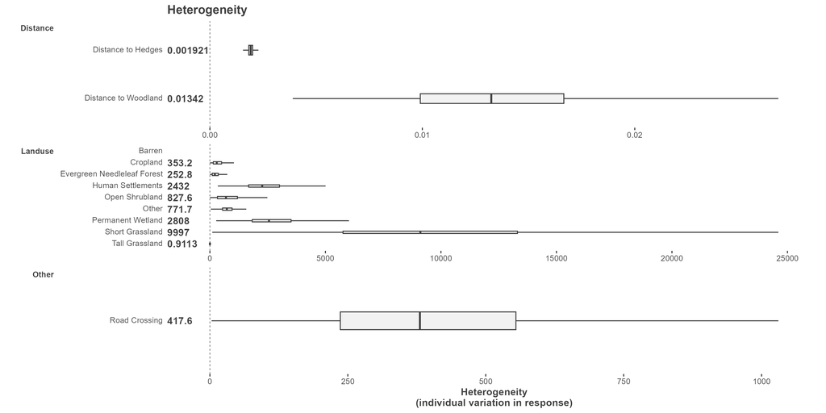

Figure 6.4: The simulated heterogeneity (standard deviation) values from coefficients and standard errors of the individual step-selection models.

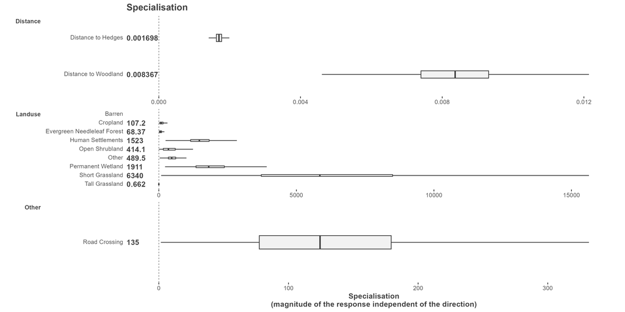

Figure 6.5: The simulated specialisation (absolute coefficients) values from individual coefficients and standard errors of the step-selection models.

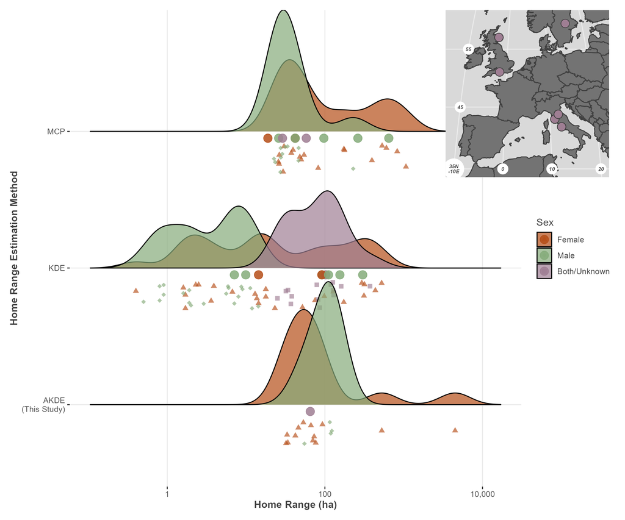

Figure 6.6: A comparison between reported annual home range sizes present in the HomeRange dataset for Roe Deer, split by estimation method. MCP = Minimum convex polygon, KDE = Kernel Density Estimation, AKDE = Autocorrelated Kernel Density Estimation. Distributions show the spread of individual home range estimates, split by sex. Small points below show the individual estimates (triangles = female; diamonds = male, squares = both/unknown). Note that individuals may appear multiple times if home range estimates were year/season specific. Larger circle points show the estimates provided as population means (total or split between sexes). Inset map shows the study locations, both points within the UK originate from this study. Note x axis is log scaled to accommodate the spread of ranges, particularly the high outliers.

# References

A. C. Davison, D. V. Hinkley. 1997. *[Bootstrap methods and their applications](https://doi:10.1017/CBO9780511802843)*. Cambridge: Cambridge University Press.

Abraham JO, Mumma MA. 2021. Elevated wildlife-vehicle collision rates during the COVID-19 pandemic. *Scientific Reports* 11:20391. DOI: 10.1038/s41598-021-99233-9.

Agostinelli C, Lund U. 2024. *[R package `circular`: Circular statistics (version 0.5-1)](https://CRAN.R-project.org/package=circular)*.

Aiello V, Lovari S, Bocci A. 2013. Ranging behaviour and reproductive rate in the threatened population of roe deer in Gargano, South Italy. *Italian Journal of Zoology* 80:614–619. DOI: 10.1080/11250003.2013.827752.

Allaire J, Xie Y, Dervieux C, McPherson J, Luraschi J, Ushey K, Atkins A, Wickham H, Cheng J, Chang W, Iannone R. 2024. *[rmarkdown: Dynamic documents for r](https://github.com/rstudio/rmarkdown)*.

Angelo Canty, B. D. Ripley. 2024. *boot: Bootstrap r (s-plus) functions*.

Basak SM, Wierzbowska IA, Gajda A, Czarnoleski M, Lesiak M, Widera E. 2020. Human–wildlife conflicts in krakow city, southern poland. *Animals* 10:1014.

Bastille-Rousseau G. 2025. *[IndRSA: An r package for individual-level resource selection analysis](https://github.com/BastilleRousseau/IndRSA)*.

Bastille‐Rousseau G, Wittemyer G. 2022. Simple metrics to characterize inter‐individual and temporal variation in habitat selection behaviour. *Journal of Animal Ecology* 91:1693–1706. DOI: 10.1111/1365-2656.13738.

Bates D, Mächler M, Bolker B, Walker S. 2015. Fitting linear mixed-effects models using lme4. *Journal of Statistical Software* 67:1–48. DOI: 10.18637/jss.v067.i01.

Bevanda M, Fronhofer EA, Heurich M, Müller J, Reineking B. 2015. Landscape configuration is a major determinant of home range size variation. *Ecosphere* 6:1–12. DOI: 10.1890/ES15-00154.1.

Bideau E, Gerard JF, Vincent JP, Maublanc ML. 1993. Effects of Age and Sex on Space Occupation by European Roe Deer. *Journal of Mammalogy* 74:745–751. DOI: 10.2307/1382297.

Biosa D, Grignolio S, Sica N, Pagon N, Scandura M, Apollonio M. 2015. Do relatives like to stay closer? Spatial organization and genetic relatedness in a mountain roe deer population. *Journal of Zoology* 296:30–37. DOI: 10.1111/jzo.12214.

Bivand RS, Pebesma E, Gomez-Rubio V. 2013. *[Applied spatial data analysis with R, second edition](https://asdar-book.org/)*. Springer, NY.

Blender Online Community. 2025. *[Blender - a 3D modelling and rendering package](http://www.blender.org)*. Blender Institute, Amsterdam: Blender Foundation.

Bonnot N, Verheyden H, Blanchard P, Cote J, Debeffe L, Cargnelutti B, Klein F, Hewison AJM, Morellet N. 2015. Interindividual variability in habitat use: Evidence for a risk management syndrome in roe deer? *Behavioral Ecology* 26:105–114. DOI: 10.1093/beheco/aru169.

Broekman MJE, Hilbers JP, Hoeks S, Huijbregts MAJ, Schipper AM, Tucker MA. 2024. Environmental drivers of global variation in home range size of terrestrial and marine mammals. *Journal of Animal Ecology* 93:488–500. DOI: 10.1111/1365-2656.14073.

Broekman M, Hoeks S, Freriks R, Langendoen M, Runge K, Savenco E, Ter Harmsel R, Huijbregts M, Tucker M. 2022. HomeRange: A global database of mammalian home ranges. DOI: 10.5061/DRYAD.D2547D85X.

Broekman MJE, Hoeks S, Freriks R, Langendoen MM, Runge KM, Savenco E, Ter Harmsel R, Huijbregts MAJ, Tucker MA. 2023. *HomeRange* : A global database of mammalian home ranges. *Global Ecology and Biogeography* 32:198–205. DOI: 10.1111/geb.13625.

Burbaiteė L, Csányi S. 2009. Roe deer population and harvest changes in europe. *Estonian Journal of Ecology* 58.

Calabrese JM, Fleming CH, Gurarie E. 2016. Ctmm: An R Package for Analyzing Animal Relocation Data As a Continuous-Time Stochastic Process. *Methods in Ecology and Evolution* 7:1124–1132. DOI: 10.1111/2041-210X.12559.

Carvalho P, Nogueira AJA, Soares AMVM, Fonseca C. 2008. Ranging behaviour of translocated roe deer in a Mediterranean habitat: Seasonal and altitudinal influences on home range size and patterns of range use. *mammalia* 72. DOI: 10.1515/MAMM.2008.019.

Catt DC, Staines BW. 1987. Home range use and habitat selection by Red deer ( *Cerrus elaphus* ) in a Sitka spruce plantation as determined by radio‐tracking. *Journal of Zoology* 211:681–693. DOI: 10.1111/j.1469-7998.1987.tb04479.x.

Cederlund G. 1983. Home range dynamics and habitat selection by roe deer in a boreal area in central Sweden. *Acta Theriologica* 28:443–460. DOI: 10.4098/AT.arch.83-39.

Chapman NG, Claydon K, Claydon M, Forde PG, Harris S. 1993. Sympatric populations of muntjac (Muntiacus reevesi) and roe deer (Capreolus capreolus): A comparative analysis of their ranging behaviour, social organization and activity. *Journal of Zoology* 229:623–640. DOI: 10.1111/j.1469-7998.1993.tb02660.x.

Cimino L, Lovari S. 2003. The effects of food or cover removal on spacing patterns and habitat use in roe deer ( *Capreolus capreolus* ). *Journal of Zoology* 261:299–305. DOI: 10.1017/S0952836903004229.

Cockburn R. 1976. Catching roe deer alive in long nets. *Deer* 3:434–440.

Corporation M, Weston S. 2022. *[doParallel: Foreach parallel adaptor for the “parallel” package](https://CRAN.R-project.org/package=doParallel)*.

Cunningham CX, Nuñez TA, Hentati Y, Sullender B, Breen C, Ganz TR, Kreling SES, Shively KA, Reese E, Miles J, Prugh LR. 2022. Permanent daylight saving time would reduce deer-vehicle collisions. *Current Biology* 32:4982–4988.e4. DOI: 10.1016/j.cub.2022.10.007.

Debeffe L, Morellet N, Cargnelutti B, Lourtet B, Bon R, Gaillard J, Mark Hewison AJ. 2012. Condition‐dependent natal dispersal in a large herbivore: Heavier animals show a greater propensity to disperse and travel further. *Journal of Animal Ecology* 81:1327–1327. DOI: 10.1111/j.1365-2656.2012.02014.x.

Denneboom D, Bar‐Massada A, Shwartz A. 2024. Wildlife mortality risk posed by high and low traffic roads. *Conservation Biology* 38:e14159. DOI: 10.1111/cobi.14159.

Doherty TS, Driscoll DA. 2018. Coupling movement and landscape ecology for animal conservation in production landscapes. *Proceedings of the Royal Society B: Biological Sciences* 285:20172272. DOI: 10.1098/rspb.2017.2272.

Dupke C, Bonenfant C, Reineking B, Hable R, Zeppenfeld T, Ewald M, Heurich M. 2017. Habitat selection by a large herbivore at multiple spatial and temporal scales is primarily governed by food resources. *Ecography* 40:1014–1027. DOI: 10.1111/ecog.02152.

Ewald M, Dupke C, Heurich M, Müller J, Reineking B. 2014. LiDAR remote sensing of forest structure and GPS telemetry data provide insights on winter habitat selection of european roe deer. *Forests* 5:1374–1390.

Fleming CH, Calabrese JM. 2017. A new kernel density estimator for accurate home-range and species-range area estimation. *Methods in Ecology and Evolution* 8:571–579. DOI: 10.1111/2041-210X.12673.

Fleming CH, Calabrese JM. 2023. *[ctmm: Continuous-time movement modeling](https://CRAN.R-project.org/package=ctmm)*.

Fleming CH, Fagan WF, Mueller T, Olson KA, Leimgruber P, Calabrese JM. 2015. Rigorous home range estimation with movement data: A new autocorrelated kernel density estimator. *Ecology* 96:1182–1188.

Fleming CH, Noonan MJ, Medici EP, Calabrese JM. 2019. Overcoming the challenge of small effective sample sizes in home‐range estimation. *Methods in Ecology and Evolution* 10:1679–1689. DOI: 10.1111/2041-210X.13270.

Focardi S, Aragno P, Montanaro P, Riga F. 2006. Inter‐specific competition from fallow deer *Dama dama* reduces habitat quality for the Italian roe deer *Capreolus capreolus italicus*. *Ecography* 29:407–417. DOI: 10.1111/j.2006.0906-7590.04442.x.

Fox J. 2003. Effect displays in R for generalised linear models. *Journal of Statistical Software* 8:1–27. DOI: 10.18637/jss.v008.i15.

Fox J, Hong J. 2009. Effect displays in R for multinomial and proportional-odds logit models: Extensions to the effects package. *Journal of Statistical Software* 32:1–24. DOI: 10.18637/jss.v032.i01.

Fox J, Weisberg S. 2018. Visualizing fit and lack of fit in complex regression models with predictor effect plots and partial residuals. *Journal of Statistical Software* 87:1–27. DOI: 10.18637/jss.v087.i09.

Fox J, Weisberg S. 2019. *[An r companion to applied regression](https://socialsciences.mcmaster.ca/jfox/Books/Companion/index.html)*. Thousand Oaks CA: Sage.

Gallagher AJ, Creel S, Wilson RP, Cooke SJ. 2017. Energy Landscapes and the Landscape of Fear. *Trends in Ecology & Evolution* 32:88–96. DOI: 10.1016/j.tree.2016.10.010.

Gill RMA, Johnson AL, Francis A, Hiscocks K, Peace AJ. 1996. Changes in roe deer (capreolus capreolus l.) population density in response to forest habitat succession. *Forest Ecology and Management* 88:31–41. DOI: https://doi.org/10.1016/S0378-1127(96)03807-8.

Gomez S, English HM, Bejarano Alegre V, Blackwell PG, Bracken AM, Bray E, Evans LC, Gan JL, Grecian WJ, Gutmann Roberts C, Harju SM, Hejcmanová P, Lelotte L, Marshall BM, Matthiopoulos J, Mnenge AJ, Niebuhr BB, Ortega Z, Pollock CJ, Potts JR, Russell CJG, Rutz C, Singh NJ, Whyte KF, Börger L. 2025. Understanding and predicting animal movements and distributions in the Anthropocene. *Journal of Animal Ecology*:1365–2656.70040. DOI: 10.1111/1365-2656.70040.

Hernangómez D. 2023. Using the tidyverse with terra objects: The tidyterra package. *Journal of Open Source Software* 8:5751. DOI: 10.21105/joss.05751.

Hester J, Bryan J. 2024. *[glue: Interpreted string literals](https://CRAN.R-project.org/package=glue)*.

Hewison AJM, Morellet N, Verheyden H, Daufresne T, Angibault J, Cargnelutti B, Merlet J, Picot D, Rames J, Joachim J, Lourtet B, Serrano E, Bideau E, Cebe N. 2009. Landscape fragmentation influences winter body mass of roe deer. *Ecography* 32:1062–1070. DOI: 10.1111/j.1600-0587.2009.05888.x.

Hewison AJ, Vincent JP, Joachim J, Angibault JM, Cargnelutti B, Cibien C. 2001. The effects of woodland fragmentation and human activity on roe deer distribution in agricultural landscapes. *Canadian Journal of Zoology* 79:679–689. DOI: 10.1139/z01-032.

Hijmans RJ. 2024a. *[raster: Geographic data analysis and modeling](https://CRAN.R-project.org/package=raster)*.

Hijmans RJ. 2024b. *[terra: Spatial data analysis](https://CRAN.R-project.org/package=terra)*.

Hoem SA, Melis C, Linnell JDC, Andersen R. 2007. Fighting behaviour in territorial male roe deer Capreolus capreolus: The effects of antler size and residence. *European Journal of Wildlife Research* 53:1–8. DOI: 10.1007/s10344-006-0053-3.

Jackson D. 2000. *[Guidance on the interpretation of the Biodiversity Broad Habitat Classification (terrestrial and freshwater types): Definitions and the relationship with other habitat classifications](http://www.jncc.gov.uk/page-2433)*. Joint Nature Conservation Committee.

Jeppesen JL. 1990. Home range and movements of free-ranging roe deer (Capreolus capreolus) at Kalø. *Danish Review of Game Biology (Denmark)* 14.

Jepsen J, Topping C. 2004. Modelling roe deer (capreolus capreolus) in a gradient of forest fragmentation: Behavioural plasticity and choice of cover. *Canadian journal of zoology* 82:1528–1541.

Jerina K. 2012. Roads and supplemental feeding affect home-range size of slovenian red deer more than natural factors. *Journal of Mammalogy* 93:1139–1148.

Jones PF, Jakes AF, Telander AC, Sawyer H, Martin BH, Hebblewhite M. 2019. Fences reduce habitat for a partially migratory ungulate in the northern sagebrush steppe. *Ecosphere* 10:e02782.

Kämmerle J-L, Brieger F, Kröschel M, Hagen R, Storch I, Suchant R. 2017. Temporal patterns in road crossing behaviour in roe deer (Capreolus capreolus) at sites with wildlife warning reflectors. *PLOS ONE* 12:e0184761. DOI: 10.1371/journal.pone.0184761.

Kay M. 2024a. ggdist: Visualizations of distributions and uncertainty in the grammar of graphics. *IEEE Transactions on Visualization and Computer Graphics* 30:414–424. DOI: 10.1109/TVCG.2023.3327195.

Kay M. 2024b. *ggdist: Visualizations of distributions and uncertainty*. DOI: 10.5281/zenodo.3879620.

Kjellander P, Hewison AJM, Liberg O, Angibault J-M, Bideau E, Cargnelutti B. 2004. Experimental evidence for density-dependence of home-range size in roe deer ( Capreolus capreolus L.): A comparison of two long-term studies. *Oecologia* 139:478–485. DOI: 10.1007/s00442-004-1529-z.

Kranstauber B, Smolla M, Scharf AK. 2024. *[move: Visualizing and analyzing animal track data](https://CRAN.R-project.org/package=move)*.

Lamberti P, Mauri L, Apollonio M. 2004. Two distinct patterns of spatial behaviour of female roe deer ( *Capreolus capreolus* ) in a mountainous habitat. *Ethology Ecology & Evolution* 16:41–53. DOI: 10.1080/08927014.2004.9522653.

Lamberti P, Mauri L, Merli E, Dusi S, Apollonio M. 2006. Use of space and habitat selection by roe deer Capreolus capreolus in a Mediterranean coastal area: How does woods landscape affect home range? *Journal of Ethology* 24:181–188. DOI: 10.1007/s10164-005-0179-x.

Lamberti P, Rossi I, Mauri L, Apollonio M. 2001. Alternative use of space strategies of female roe deer *(Capreolus capreolus)* in a mountainous habitat. *Italian Journal of Zoology* 68:69–73. DOI: 10.1080/11250000109356385.

Landau WM. 2021a. *tarchetypes: Archetypes for targets*.

Landau WM. 2021b. [The targets r package: A dynamic make-like function-oriented pipeline toolkit for reproducibility and high-performance computing](https://doi.org/10.21105/joss.02959). *Journal of Open Source Software* 6:2959.

Langbein J. 2019. *Deer-vehicle collision (DVC) data collection and analysis 2016-2018*. Scottish Natural Heritage.

Lindgren F, Rue H. 2015. [Bayesian spatial modelling with R-INLA](http://www.jstatsoft.org/v63/i19/). *Journal of Statistical Software* 63:1–25.

Linnell JDC, Andersen R. 1995. [Site Tenacity in Roe Deer: Short-Term Effects of Logging](http://www.jstor.org/stable/3783190). *Wildlife Society Bulletin (1973-2006)* 23:31–35.

Lone K, Loe LE, Gobakken T, Linnell JDC, Odden J, Remmen J, Mysterud A. 2014. Living and dying in a multi‐predator landscape of fear: Roe deer are squeezed by contrasting pattern of predation risk imposed by lynx and humans. *Oikos* 123:641–651. DOI: 10.1111/j.1600-0706.2013.00938.x.

Lüdecke D. 2018. sjmisc: Data and variable transformation functions. *Journal of Open Source Software* 3:754. DOI: 10.21105/joss.00754.

Lüdecke D, Ben-Shachar MS, Patil I, Waggoner P, Makowski D. 2021. performance: An R package for assessment, comparison and testing of statistical models. *Journal of Open Source Software* 6:3139. DOI: 10.21105/joss.03139.

Lush M, Lush C. 2026. Deer vehicle collision analysis 2022–2024. *NatureScot Research Report* 1400.

Malagnino A, Marchand P, Garel M, Cargnelutti B, Itty C, Chaval Y, Hewison AJM, Loison A, Morellet N. 2021. Do reproductive constraints or experience drive age-dependent space use in two large herbivores? *Animal Behaviour* 172:121–133. DOI: 10.1016/j.anbehav.2020.12.004.

Manly BFJ, McDonald LL, Thomas DL. 1993. *Resource Selection by Animals*. Dordrecht: Springer Netherlands. DOI: 10.1007/978-94-011-1558-2.

Martins TG, Simpson D, Lindgren F, Rue H. 2013. Bayesian computing with INLA: New features. *Computational Statistics and Data Analysis* 67:68–83.

Märtz J, Brieger F, Bhardwaj M. 2024. Crossings and collisions – Exploring how roe deer navigate the road network. *Landscape Ecology* 39:101. DOI: 10.1007/s10980-024-01897-x.

Matthiopoulos J, Fieberg J, Aarts G, Beyer HL, Morales JM, Haydon DT. 2015. Establishing the link between habitat selection and animal population dynamics. *Ecological Monographs* 85:413–436. DOI: 10.1890/14-2244.1.

Maublanc M-L, Daubord L, Bideau É, Gerard J-F. 2018. Experimental evidence of socio-spatial intolerance between female roe deer. *Ethology Ecology & Evolution* 30:461–476. DOI: 10.1080/03949370.2017.1423116.

Melis C, Cagnacci F, Lovari S. 2005. Do male roe deer clump together during the rut? *Acta Theriologica* 50:253–262. DOI: 10.1007/BF03194488.

Microsoft, Weston S. 2022. *[foreach: Provides foreach looping construct](https://CRAN.R-project.org/package=foreach)*.

Mitchell B, Staines BW, Welch D. 1977. *Ecology of red deer: A research review relevant to their management in scotland*. Institute of Terrestrial Ecology.

Morellet N, Bonenfant C, Börger L, Ossi F, Cagnacci F, Heurich M, Kjellander P, Linnell JDC, Nicoloso S, Sustr P, Urbano F, Mysterud A. 2013. Seasonality, weather and climate affect home range size in roe deer across a wide latitudinal gradient within <span style="font-variant:small-caps;">E</span> urope. *Journal of Animal Ecology* 82:1326–1339. DOI: 10.1111/1365-2656.12105.

Morellet N, Van Moorter B, Cargnelutti B, Angibault J-M, Lourtet B, Merlet J, Ladet S, Hewison AJM. 2011. Landscape composition influences roe deer habitat selection at both home range and landscape scales. *Landscape Ecology* 26:999–1010. DOI: 10.1007/s10980-011-9624-0.

Morellet N, Verheyden H, Angibault J-M, Cargnelutti B, Lourtet B, Hewison MAJ. 2009. The effect of capture on ranging behaviour and activity of the european roe deer capreolus capreolus. *Wildlife Biology* 15:278–287. DOI: https://doi.org/10.2981/08-084.

Morton RD, Marston CG, O’Neil AW, Rowland CS. 2024. Land Cover Map 2023 (25m rasterised land parcels, GB). DOI: 10.5285/AB10EA4A-1788-4D25-A6DF-F1AFF829DFFF.

Morton D, Rowland C, Wood C, Meek L, Marston C, Smith G, Wadsworth R, Simpson I. 2011. *Final report for LCM2007-the new UK land cover map. Countryside survey technical report no 11/07*. NERC/CENTRE FOR ECOLOGY & HYDROLOGY.

Muff S, Signer J, Fieberg J. 2020. Accounting for individual‐specific variation in habitat‐selection studies: Efficient estimation of mixed‐effects models using Bayesian or frequentist computation. *Journal of Animal Ecology* 89:80–92. DOI: 10.1111/1365-2656.13087.

Müller K. 2020. *[here: A simpler way to find your files](https://CRAN.R-project.org/package=here)*.

Mysterud A. 1999. Seasonal migration pattern and home range of roe deer ( *Capreolus capreolus* ) in an altitudinal gradient in southern Norway. *Journal of Zoology* 247:479–486. DOI: 10.1111/j.1469-7998.1999.tb01011.x.

Mysterud A, Rivrud IM, Meisingset EL, Jore S, Viljugrein H. 2025. Deer migration, deer density, tick distribution and incidence of a tick‐borne zoonosis. *Journal of Animal Ecology* 94:2655–2670. DOI: 10.1111/1365-2656.70163.

Nelli L, Langbein J, Watson P, Putman R. 2018. Mapping risk: Quantifying and predicting the risk of deer-vehicle collisions on major roads in England. *Mammalian Biology* 91:71–78. DOI: 10.1016/j.mambio.2018.03.013.

Ordnance Survey. 2024. [OS Open Roads v.2.4](https://osdatahub.os.uk/downloads/open/OpenRoads).

Padié S, Morellet N, Hewison AJM, Martin J, Bonnot N, Cargnelutti B, Chamaillé‐Jammes S. 2015. Roe deer at risk: Teasing apart habitat selection and landscape constraints in risk exposure at multiple scales. *Oikos* 124:1536–1546. DOI: 10.1111/oik.02115.

Pagon N, Grignolio S, Brivio F, Marcon A, Apollonio M. 2017. Territorial behaviour of male roe deer: A telemetry study of spatial behaviour and activity levels. *Folia Zoologica* 66:267–276. DOI: 10.25225/fozo.v66.i4.a9.2017.

Passoni G, Coulson T, Ranc N, Corradini A, Hewison AJM, Ciuti S, Gehr B, Heurich M, Brieger F, Sandfort R, Mysterud A, Balkenhol N, Cagnacci F. 2021. Roads constrain movement across behavioural processes in a partially migratory ungulate. *Movement Ecology* 9:57. DOI: 10.1186/s40462-021-00292-4.

Pebesma E. 2018. Simple Features for R: Standardized Support for Spatial Vector Data. *The R Journal* 10:439–446. DOI: 10.32614/RJ-2018-009.

Pebesma EJ, Bivand R. 2005. [Classes and methods for spatial data in R](https://CRAN.R-project.org/doc/Rnews/). *R News* 5:9–13.

Pebesma E, Bivand R. 2023. *Spatial Data Science: With applications in R*. Chapman and Hall/CRC. DOI: 10.1201/9780429459016.

Pebesma E, Mailund T, Hiebert J. 2016. Measurement units in R. *R Journal* 8:486–494. DOI: 10.32614/RJ-2016-061.

Pedersen TL. 2024. *[patchwork: The composer of plots](https://CRAN.R-project.org/package=patchwork)*.

Pellerin M, Picard M, Saïd S, Baubet E, Baltzinger C. 2016. Complementary endozoochorous long-distance seed dispersal by three native herbivorous ungulates in Europe. *Basic and Applied Ecology* 17:321–332. DOI: 10.1016/j.baae.2016.01.005.

Pepper S, Barbour A, Glass J. 2020. *The management of wild deer in scotland: Report of the deer working group*. Scottish Government, Environment; Forestry Directorate.

Picardi S, Basille M, Peters W, Ponciano JM, Boitani L, Cagnacci F. 2019. Movement responses of roe deer to hunting risk. *The Journal of Wildlife Management* 83:43–51. DOI: 10.1002/jwmg.21576.

Posit team. 2024. *[RStudio: Integrated development environment for r](http://www.posit.co/)*. Boston, MA: Posit Software, PBC.

Putman R, Langbein J, Green P, Watson P. 2011. Identifying threshold densities for wild deer in the UK above which negative impacts may occur. *Mammal Review* 41:175–196. DOI: 10.1111/j.1365-2907.2010.00173.x.

R Core Team. 2024. *[R: A language and environment for statistical computing](https://www.R-project.org/)*. Vienna, Austria: R Foundation for Statistical Computing.

Ramanzin M, Sturaro E, Zanon D. 2007. Seasonal migration and home range of roe deer ( *Capreolus capreolus* ) in the Italian eastern Alps. *Canadian Journal of Zoology* 85:280–289. DOI: 10.1139/Z06-210.

Ranc N, Moorcroft PR, Hansen KW, Ossi F, Sforna T, Ferraro E, Brugnoli A, Cagnacci F. 2020. Preference and familiarity mediate spatial responses of a large herbivore to experimental manipulation of resource availability. *Scientific Reports* 10:11946. DOI: 10.1038/s41598-020-68046-7.

Redpath SM. 1995. Impact of habitat fragmentation on activity and hunting behavior in the tawny owl, *Strix aluco*. *Behavioral Ecology* 6:410–413. DOI: 10.1093/beheco/6.4.410.

Richard E, Morellet N, Cargnelutti B, Angibault JM, Vanpé C, Hewison AJM. 2008. Ranging behaviour and excursions of female roe deer during the rut. *Behavioural Processes* 79:28–35. DOI: 10.1016/j.beproc.2008.04.008.

Rossi I, Lamberti P, Mauri L, Apollonio M. 2001. Male and female spatial behaviour of roe deer in a mountainous habitat during pre-rutting and rutting period. *Journal of Mountain Ecology* 6:1–6.

Rossi I, Lamberti P, Mauri L, Apollonio M. 2003. Home range dynamics of male roe deer Capreolus capreolus in a mountainous habitat. *Acta Theriologica* 48:425–432. DOI: 10.1007/BF03194180.

Saïd S, Gaillard J, Duncan P, Guillon N, Guillon N, Servanty S, Pellerin M, Lefeuvre K, Martin C, Van Laere G. 2005. Ecological correlates of home‐range size in spring–summer for female roe deer ( *Capreolus capreolus* ) in a deciduous woodland. *Journal of Zoology* 267:301–308. DOI: 10.1017/S0952836905007454.

Saïd S, Gaillard J, Widmer O, Débias F, Bourgoin G, Delorme D, Roux C. 2009. What shapes intra‐specific variation in home range size? A case study of female roe deer. *Oikos* 118:1299–1306. DOI: 10.1111/j.1600-0706.2009.17346.x.

Saïd S, Servanty S. 2005. The Influence of Landscape Structure on Female Roe Deer Home-range Size. *Landscape Ecology* 20:1003–1012. DOI: 10.1007/s10980-005-7518-8.

Saunders DA. 1982. The breeding behaviour and biology of the short‐billed form of the white‐tailed black cockatoo *Calyptorhynchus funereus*. *Ibis* 124:422–455. DOI: 10.1111/j.1474-919X.1982.tb03790.x.

Sawyer H, Kauffman MJ, Middleton AD, Morrison TA, Nielson RM, Wyckoff TB. 2013. A framework for understanding semi‐permeable barrier effects on migratory ungulates. *Journal of Applied Ecology* 50:68–78. DOI: 10.1111/1365-2664.12013.

Scholefield PA, Morton RD, Rowland CS, Henrys PA, Howard DC, Norton LR. 2016. Woody linear features framework, Great Britain v.1.0. DOI: 10.5285/D7DA6CB9-104B-4DBC-B709-C1F7BA94FB16.

Schwandner IA, Morrison TA, Hopcraft JGC, Wall J, Hughey L, Boone RB, Ogutu JO, Jakes AF, Kifugo SC, Limo C, Ndambuki Mwiu S, Nyaga V, Olff H, Ojwang GO, Sairowua W, Sasine J, Senteu JS, Sopia D, Worden J, Stabach JA. 2025. Predicting the impact of targeted fence removal on connectivity in a migratory ecosystem. *Ecological Applications* 35:e3094. DOI: 10.1002/eap.3094.

Serif. 2025. Affinity Publisher 2.

Serota MW, Alarcón PAE, Donadio E, Middleton AD. 2024. Behavioral state-dependent selection of roads by guanacos. *Landscape Ecology* 39:110. DOI: 10.1007/s10980-024-01909-w.

Signer J, Fieberg J, Avgar T. 2019. Animal movement tools (amt): R package for managing tracking data and conducting habitat selection analyses. *Ecology and Evolution* 9:880–890.

Silva I, Crane M, Marshall BM, Strine CT. 2020. Reptiles on the wrong track? Moving beyond traditional estimators with dynamic Brownian Bridge Movement Models. *Movement Ecology* 8:43. DOI: 10.1186/s40462-020-00229-3.

Silva I, Fleming CH, Noonan MJ, Alston J, Folta C, Fagan WF, Calabrese JM. 2022. Autocorrelation‐informed home range estimation: A review and practical guide. *Methods in Ecology and Evolution* 13:534–544. DOI: 10.1111/2041-210X.13786.

Staines B, Palmer S, Wyllie I, Gill R, Mayle B. 1998. Final project report to the ministry of agriculture, fisheries and food: Desk and limited field studies to analyse the major factor influencing regional deer populations and ranging behaviour. *Institute of Terrestrial Ecology, Natural Environmental Research Council* T08093A5 & B5:1–97.

Tucker MA, Böhning-Gaese K, Fagan WF, Fryxell JM, Van Moorter B, Alberts SC, Ali AH, Allen AM, Attias N, Avgar T, others. 2018. Moving in the anthropocene: Global reductions in terrestrial mammalian movements. *Science* 359:466–469.

Tufto J, Andersen R, Linnell J. 1996. Habitat Use and Ecological Correlates of Home Range Size in a Small Cervid: The Roe Deer. *The Journal of Animal Ecology* 65:715. DOI: 10.2307/5670.

Valero E, Picos J, Lagos L, Álvarez X. 2015. Corrigendum to: Road and traffic factors correlated to wildlife–vehicle collisions in Galicia (Spain). *Wildlife Research* 42:717. DOI: 10.1071/WR14060_CO.

van Etten J. 2017. R package gdistance: Distances and routes on geographical grids. *Journal of Statistical Software* 76:1–21. DOI: 10.18637/jss.v076.i13.

Van Laere G, Boutin JM, Gaillard JM. 1996. Utilisation de l’espace par le faon de chevreuil, Capreolus capreolus L. (Artiodactyla, Cervidae), durant ses premiers mois de vie. *Mammalia* 60. DOI: 10.1515/mamm.1996.60.1.15.

Vanpé C, Morellet N, Kjellander P, Goulard M, Liberg O, Hewison AJM. 2009. Access to mates in a territorial ungulate is determined by the size of a male’s territory, but not by its habitat quality. *Journal of Animal Ecology* 78:42–51. DOI: 10.1111/j.1365-2656.2008.01467.x.

Venkatesan S, Marshall B, Greener M, Kinghorn A, Sligo-Young I, Hassall R, Gill R, McKeown B, Hall J, Biek R, Gilbert L, Morrison T, Millins C. IN PREP - 2026. Drivers of roe deer use of fragmented forest landscapes; implications for management in the context of policy driven forest expansion. *IN PREP*.

Webster MM, Rutz C. 2020. How STRANGE are your study animals? *Nature* 582:337–340. DOI: 10.1038/d41586-020-01751-5.

Wickham H, Averick M, Bryan J, Chang W, McGowan LD, François R, Grolemund G, Hayes A, Henry L, Hester J, Kuhn M, Pedersen TL, Miller E, Bache SM, Müller K, Ooms J, Robinson D, Seidel DP, Spinu V, Takahashi K, Vaughan D, Wilke C, Woo K, Yutani H. 2019. Welcome to the tidyverse. *Journal of Open Source Software* 4:1686. DOI: 10.21105/joss.01686.

Wickham H, Bryan J, Barrett M, Teucher A. 2024. *[usethis: Automate package and project setup](https://CRAN.R-project.org/package=usethis)*.

Wickham H, Pedersen TL, Seidel D. 2023. *[scales: Scale functions for visualization](https://CRAN.R-project.org/package=scales)*.

Wilke CO. 2024. *[ggridges: Ridgeline plots in “ggplot2”](https://CRAN.R-project.org/package=ggridges)*.

Wilke CO, Wiernik BM. 2022. *[ggtext: Improved text rendering support for “ggplot2”](https://CRAN.R-project.org/package=ggtext)*.

Xie Y. 2014. knitr: A comprehensive tool for reproducible research in R. In: Stodden V, Leisch F, Peng RD eds. *Implementing reproducible computational research*. Chapman; Hall/CRC,.

Xie Y. 2015. *[Dynamic documents with R and knitr](https://yihui.org/knitr/)*. Boca Raton, Florida: Chapman; Hall/CRC.

Xie Y. 2016. *[bookdown: Authoring books and technical documents with R markdown](https://bookdown.org/yihui/bookdown)*. Boca Raton, Florida: Chapman; Hall/CRC.

Xie Y. 2024. *[knitr: A general-purpose package for dynamic report generation in r](https://yihui.org/knitr/)*.

Xie Y. 2025. *[bookdown: Authoring books and technical documents with r markdown](https://github.com/rstudio/bookdown)*.

Xie Y, Allaire JJ, Grolemund G. 2018. *[R markdown: The definitive guide](https://bookdown.org/yihui/rmarkdown)*. Boca Raton, Florida: Chapman; Hall/CRC.

Xie Y, Dervieux C, Riederer E. 2020. *[R markdown cookbook](https://bookdown.org/yihui/rmarkdown-cookbook)*. Boca Raton, Florida: Chapman; Hall/CRC.

Xu W, Dejid N, Herrmann V, Sawyer H, Middleton AD. 2021. Barrier Behaviour Analysis (BaBA) reveals extensive effects of fencing on wide‐ranging ungulates. *Journal of Applied Ecology* 58:690–698. DOI: 10.1111/1365-2664.13806.